# CSCI E-89: Homework 4

Paul Schwartzberg

## Problem 1: recognise handwritten digits

Adapted from the course notebook `1_pytorch_basic_cnn_digits.ipynb`. We replace scikit-learn's 8 x 8 digit images with MNIST images from torchvision. Each MNIST image has 28 x 28 pixels.

**Progress:** Problem 1 is complete: 98.26% MNIST test accuracy and four correct predictions on five personal Paint drawings.

### 1. Set up the environment

Use the `cscie89` kernel. The printed Python path lets us check that the notebook uses the intended environment. A convolutional neural network (CNN) learns image features through filters whose weights change during training.

```python
import random
import sys
from pathlib import Path

import matplotlib.pyplot as plt
import numpy as np
import torch
import torchvision
from torchvision import datasets, transforms

# Fixed seeds make later splits and model initialisation more repeatable.
SEED = 42
random.seed(SEED)
np.random.seed(SEED)
torch.manual_seed(SEED)

device = torch.device("cuda" if torch.cuda.is_available() else "cpu")
print(f"Python executable: {sys.executable}")
print(f"PyTorch: {torch.__version__}")
print(f"torchvision: {torchvision.__version__}")
print(f"Device: {device}")
```

```
Python executable: C:\Users\schwa\.conda\envs\cscie89\python.exe
PyTorch: 2.14.0+cpu
torchvision: 0.29.0+cpu
Device: cpu
```

### 2. Load MNIST through torchvision

A `Dataset` provides an image and its label when we request an item. `datasets.MNIST` supplies the images; `ToTensor()` converts them to the format PyTorch needs.

MNIST has 60,000 training images and 10,000 test images.  
We will later divide the training pool into training and validation sets.  
The test set stays separate until final evaluation.

The shape `(1, 28, 28)` means one colour channel, 28 rows and 28 columns.  
Labels are integers from 0 to 9.  
The first run downloads the data; later runs reuse the local files.

```python
# ToTensor converts each greyscale image to a float tensor of shape
# (1, 28, 28) and scales its pixel values from 0-255 to 0-1.
transform = transforms.ToTensor()
DATA_DIR = Path("data")

mnist_train_full = datasets.MNIST(
    root=DATA_DIR, train=True, download=True, transform=transform
)
mnist_test = datasets.MNIST(
    root=DATA_DIR, train=False, download=True, transform=transform
)

# Inspect a training example; keep the test set for final evaluation.
image, label = mnist_train_full[0]
print(f"Training pool: {len(mnist_train_full):,} images")
print(f"Test set: {len(mnist_test):,} images")
print(f"One image: {tuple(image.shape)}")
print(f"Tensor type: {image.dtype}")
print(f"Pixel range in this image: {image.min().item():.1f} to {image.max().item():.1f}")
print(f"Label: {label}")
```

```
Training pool: 60,000 images
Test set: 10,000 images
One image: (1, 28, 28)
Tensor type: torch.float32
Pixel range in this image: 0.0 to 1.0
Label: 5
```

### 3. Inspect the images

Show one training example per class to check the labels and appearance.  
The digits are bright against a dark background.  
When we prepare my handwritten digits later, we will match this format.

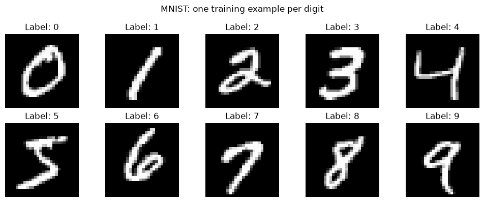

```python
# Show one training image for each digit.
fig, axes = plt.subplots(2, 5, figsize=(10, 4))
for digit, ax in enumerate(axes.flat):
    index = (mnist_train_full.targets == digit).nonzero(as_tuple=True)[0][0].item()
    image, label = mnist_train_full[index]
    ax.imshow(image.squeeze(0), cmap="gray", vmin=0, vmax=1)
    ax.set_title(f"Label: {label}")
    ax.axis("off")
fig.suptitle("MNIST: one training example per digit")
plt.tight_layout()
plt.show()
```

### 1.4 Split MNIST and prepare batches

We reserve 5,000 images from the official 60,000-image training pool for validation. The remaining 55,000 images train the model. A stratified split keeps roughly the same digit proportions in each subset. The official 10,000 test images remain separate.

A `Subset` refers to chosen indices in the torchvision dataset, so images still come from `datasets.MNIST`. `DataLoader` groups them into batches. We shuffle training batches and keep validation/test order fixed.

```python
from sklearn.model_selection import train_test_split
from torch.utils.data import DataLoader, Subset

MNIST_SEED = 42
MNIST_BATCH_SIZE = 128
# Reserve validation images from the official training pool, not the test set.
mnist_indices = np.arange(len(mnist_train_full))
mnist_train_indices, mnist_val_indices = train_test_split(
    mnist_indices, test_size=5000, random_state=MNIST_SEED,
    stratify=mnist_train_full.targets.numpy(),
)
mnist_train_dataset = Subset(mnist_train_full, mnist_train_indices.tolist())
mnist_val_dataset = Subset(mnist_train_full, mnist_val_indices.tolist())
assert set(mnist_train_indices).isdisjoint(set(mnist_val_indices))
assert len(mnist_train_dataset) + len(mnist_val_dataset) == 60000
mnist_val_loader = DataLoader(mnist_val_dataset, batch_size=256, shuffle=False, num_workers=0)
mnist_test_loader = DataLoader(mnist_test, batch_size=256, shuffle=False, num_workers=0)
print(f"Training: {len(mnist_train_dataset):,}; validation: {len(mnist_val_dataset):,}; test: {len(mnist_test):,}")
```

```
Training: 55,000; validation: 5,000; test: 10,000
```

### 1.5 Adapt the course CNN to 28 x 28 images

The course model used 8 x 8 scikit-learn images. We retain its two convolutional blocks with 8 and 16 filters, but adjust the first linear layer for MNIST. Each convolution uses padding to preserve height and width; each max-pooling layer halves them: `28 -> 14 -> 7`.

After the second block, each image has shape `(16, 7, 7)`. Flattening produces 784 values, so the first linear layer takes `16 * 7 * 7` inputs. The final layer produces ten raw scores for digits 0-9. `CrossEntropyLoss` uses these scores directly, without a softmax layer.

```python
from torch import nn

class MNISTCNN(nn.Module):
    """Adapt the course's two-block CNN to one-channel 28 x 28 images."""

    def __init__(self):
        super().__init__()
        self.features = nn.Sequential(
            nn.Conv2d(1, 8, kernel_size=3, padding=1),
            nn.ReLU(),
            nn.MaxPool2d(2),                      # 28 x 28 -> 14 x 14
            nn.Conv2d(8, 16, kernel_size=3, padding=1),
            nn.ReLU(),
            nn.MaxPool2d(2),                      # 14 x 14 -> 7 x 7
        )
        self.classifier = nn.Sequential(
            nn.Flatten(),                        # 16 * 7 * 7 = 784 values
            nn.Linear(16 * 7 * 7, 32),
            nn.ReLU(),
            nn.Linear(32, 10),                    # Raw scores for digits 0-9
        )

    def forward(self, images):
        return self.classifier(self.features(images))
```

### 1.6 Train for five epochs and select weights by validation loss

An epoch is one pass through the training set. We keep this task modest: five epochs, batches of 128 and Adam with learning rate 0.001. This cell resets weights, optimiser and batch order for a fresh run.

For each batch, we clear old gradients, predict, calculate loss, backpropagate and update weights. Validation uses `eval()` and `no_grad()` and does not update weights. Loss is weighted by batch size before averaging, so a shorter final batch receives the correct weight.

We copy the weights when validation loss improves and restore the best copy after training. We print one short line per epoch. Training metrics accumulate while weights change; validation metrics use the weights at the end of the epoch.

```python
import copy
import json
import time

# This cell starts a fresh training run, even if it is executed again.
MNIST_EPOCHS = 5
MNIST_LEARNING_RATE = 0.001
torch.set_num_threads(4)
random.seed(MNIST_SEED)
np.random.seed(MNIST_SEED)
torch.manual_seed(MNIST_SEED)
mnist_device = torch.device("cuda" if torch.cuda.is_available() else "cpu")
mnist_model = MNISTCNN().to(mnist_device)
mnist_criterion = nn.CrossEntropyLoss()
mnist_optimizer = torch.optim.Adam(mnist_model.parameters(), lr=MNIST_LEARNING_RATE)
mnist_train_loader = DataLoader(
    mnist_train_dataset, batch_size=MNIST_BATCH_SIZE, shuffle=True,
    generator=torch.Generator().manual_seed(MNIST_SEED), num_workers=0,
)

def evaluate_mnist(model, loader):
    """Measure loss and accuracy without changing weights."""
    model.eval()
    loss_sum, correct, count = 0.0, 0, 0
    with torch.no_grad():
        for images, labels in loader:
            images, labels = images.to(mnist_device), labels.to(mnist_device)
            scores = model(images)
            loss_sum += mnist_criterion(scores, labels).item() * len(labels)
            correct += (scores.argmax(1) == labels).sum().item()
            count += len(labels)
    return loss_sum / count, correct / count

mnist_history = {key: [] for key in ("train_loss", "val_loss", "train_accuracy", "val_accuracy")}
mnist_best_loss, mnist_best_epoch, mnist_best_state = float("inf"), 0, None
mnist_started = time.perf_counter()
for epoch in range(1, MNIST_EPOCHS + 1):
    mnist_model.train()
    loss_sum, correct, count = 0.0, 0, 0
    for images, labels in mnist_train_loader:
        images, labels = images.to(mnist_device), labels.to(mnist_device)
        mnist_optimizer.zero_grad()                 # Clear previous gradients.
        scores = mnist_model(images)                # Calculate class scores.
        loss = mnist_criterion(scores, labels)      # Compare with correct digits.
        loss.backward()                            # Calculate gradients.
        mnist_optimizer.step()                     # Update weights.
        loss_sum += loss.item() * len(labels)
        correct += (scores.argmax(1) == labels).sum().item()
        count += len(labels)
    val_loss, val_accuracy = evaluate_mnist(mnist_model, mnist_val_loader)
    for key, value in [("train_loss", loss_sum / count), ("train_accuracy", correct / count),
                       ("val_loss", val_loss), ("val_accuracy", val_accuracy)]:
        mnist_history[key].append(value)
    if val_loss < mnist_best_loss:
        mnist_best_loss, mnist_best_epoch = val_loss, epoch
        mnist_best_state = copy.deepcopy(mnist_model.state_dict())
    print(f"Epoch {epoch}/{MNIST_EPOCHS} | train accuracy {correct/count:.2%} | "
          f"validation accuracy {val_accuracy:.2%}, loss {val_loss:.4f}", flush=True)
mnist_training_seconds = time.perf_counter() - mnist_started
mnist_model.load_state_dict(mnist_best_state)
mnist_model.eval()
print(f"Restored epoch {mnist_best_epoch}, selected by validation loss.")
```

```
Restored epoch 5, selected by validation loss.
```

### 1.7 Evaluate, save and inspect the trained model

Only after selecting the checkpoint do we evaluate the official test set. Accuracy counts correct digit predictions; cross-entropy loss also reflects the score given to the true class. The learning curves help identify overfitting, and the confusion matrix shows which digits are confused.

We save the selected weights and settings, then verify that a freshly loaded model reproduces the same scores. This checkpoint will be used for my own handwriting. The following cell produces only short metrics and two plots, rather than printing individual predictions for all 10,000 test images.

```
Test images: 10,000
Test accuracy: 98.26%; test loss: 0.0532
Saved MNIST weights and metrics; reloaded scores match.
```

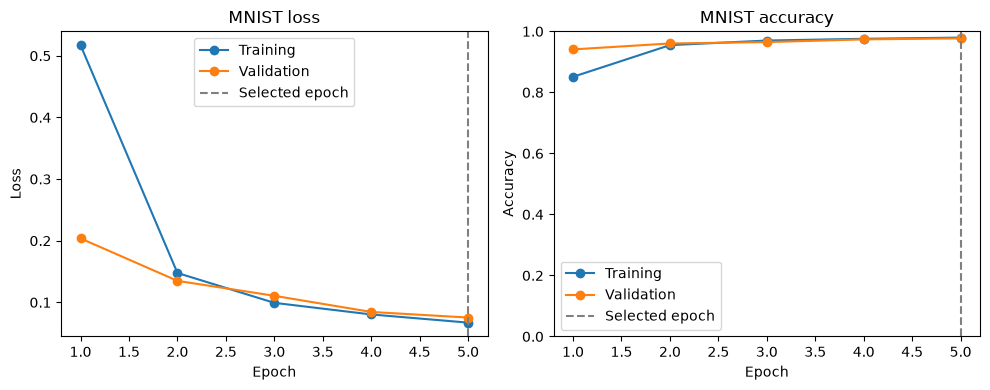

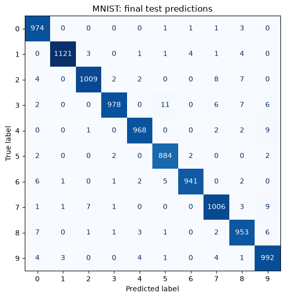

```python
from sklearn.metrics import ConfusionMatrixDisplay

# Evaluate once after selecting weights by validation loss.
mnist_true, mnist_pred = [], []
mnist_test_loss_sum = 0.0
with torch.no_grad():
    for images, labels in mnist_test_loader:
        scores = mnist_model(images.to(mnist_device))
        mnist_test_loss_sum += mnist_criterion(scores, labels.to(mnist_device)).item() * len(labels)
        mnist_true.extend(labels.tolist())
        mnist_pred.extend(scores.argmax(1).cpu().tolist())
mnist_test_accuracy = float(np.mean(np.asarray(mnist_true) == np.asarray(mnist_pred)))
mnist_test_loss = mnist_test_loss_sum / len(mnist_true)
print(f"Test images: {len(mnist_true):,}")
print(f"Test accuracy: {mnist_test_accuracy:.2%}; test loss: {mnist_test_loss:.4f}")

mnist_output_dir = Path("outputs") / "mnist"
mnist_output_dir.mkdir(parents=True, exist_ok=True)
mnist_model_path = mnist_output_dir / "mnist_cnn.pth"
torch.save({
    "state_dict": {k: v.detach().cpu() for k, v in mnist_model.state_dict().items()},
    "architecture": "MNISTCNN", "image_size": 28, "class_names": list(range(10)),
    "seed": MNIST_SEED, "best_epoch": mnist_best_epoch,
    "preprocessing": "ToTensor: bright digit on dark background; values in [0, 1]",
}, mnist_model_path)
# Check that the saved model produces the same scores as the current model.
mnist_checkpoint = torch.load(mnist_model_path, map_location=mnist_device, weights_only=True)
mnist_reloaded = MNISTCNN().to(mnist_device)
mnist_reloaded.load_state_dict(mnist_checkpoint["state_dict"])
mnist_reloaded.eval()
with torch.no_grad():
    sample = mnist_train_full[0][0].unsqueeze(0).to(mnist_device)
    torch.testing.assert_close(mnist_model(sample), mnist_reloaded(sample))
mnist_metrics = {
    "seed": MNIST_SEED, "epochs": MNIST_EPOCHS, "batch_size": MNIST_BATCH_SIZE,
    "learning_rate": MNIST_LEARNING_RATE, "best_epoch": mnist_best_epoch,
    "selected_validation_loss": mnist_best_loss,
    "selected_validation_accuracy": mnist_history["val_accuracy"][mnist_best_epoch-1],
    "test_images": len(mnist_true), "test_accuracy": mnist_test_accuracy,
    "test_loss": mnist_test_loss, "training_seconds": mnist_training_seconds,
    "history": mnist_history, "device": str(mnist_device), "pytorch_version": str(torch.__version__),
}
(mnist_output_dir / "metrics.json").write_text(json.dumps(mnist_metrics, indent=2), encoding="utf-8")
print("Saved MNIST weights and metrics; reloaded scores match.")

fig, axes = plt.subplots(1, 2, figsize=(10, 4))
for ax, metric in zip(axes, ["loss", "accuracy"]):
    ax.plot(range(1, MNIST_EPOCHS+1), mnist_history["train_"+metric], marker="o", label="Training")
    ax.plot(range(1, MNIST_EPOCHS+1), mnist_history["val_"+metric], marker="o", label="Validation")
    ax.axvline(mnist_best_epoch, color="gray", linestyle="--", label="Selected epoch")
    ax.set(xlabel="Epoch", ylabel=metric.capitalize(), title="MNIST " + metric)
    ax.legend()
axes[1].set_ylim(0, 1)
plt.tight_layout()
fig.savefig(mnist_output_dir / "learning_curves.png", dpi=120)
plt.show()

fig, ax = plt.subplots(figsize=(6, 6))
ConfusionMatrixDisplay.from_predictions(mnist_true, mnist_pred, labels=list(range(10)),
                                       cmap="Blues", colorbar=False, ax=ax)
ax.set_title("MNIST: final test predictions")
plt.tight_layout()
fig.savefig(mnist_output_dir / "test_confusion_matrix.png", dpi=120)
plt.show()
```

### 1.8 Prepare inference on five Paint images

The trained model scored 98.26% on the official MNIST test set.  
For the final part of Problem 1, I will draw five digits in Paint and use the saved model for inference only. These drawings will not train the model.

Save one digit per PNG in the repository's `handwriting/` folder.  
Digits and filenames are **0: `digit_0.png`**, **2: `digit_2.png`**, **5: `digit_5.png`**, **7: `digit_7.png`** and **8: `digit_8.png`**.  
I used a white, roughly 280 x 280 pixel canvas and a black brush about 15-20 pixels wide.  
And kept each digit centred with a clear margin.  
Draw naturally and retain misclassifications.

The following code loads the trained checkpoint.  
It converts the image to greyscale, inverts black-on-white strokes, crops blank margins, fits the digit within 20 x 20 pixels while preserving its proportions, and centres it on a black 28 x 28 canvas.  
It scales pixel values to 0-1 and rejects blank images.  
The original PNG remains unchanged. Softmax scores are not guarantees or calibrated probabilities of correctness.

**Run this code cell first.** It works in a fresh `cscie89` kernel and does not rerun training.

```python
"""Preprocess personal digit images and load the saved MNIST model for inference."""
# This section can run on its own: it loads the trained checkpoint from disk.
from pathlib import Path
import json
import numpy as np
import matplotlib.pyplot as plt
import torch
from PIL import Image, ImageOps

# MNISTCNN is defined in Section 1.5. Import it if this is a fresh kernel.
if "MNISTCNN" not in globals():
    from mnist_model import MNISTCNN

HANDWRITING_DIR = Path("handwriting")
HANDWRITING_DIR.mkdir(exist_ok=True)
handwriting_checkpoint = torch.load("outputs/mnist/mnist_cnn.pth", map_location="cpu", weights_only=True)
handwriting_model = MNISTCNN()
handwriting_model.load_state_dict(handwriting_checkpoint["state_dict"])
handwriting_model.eval()


def prepare_handwritten_image(source):
    """Convert a black-on-white drawing to a centred, bright 28 x 28 MNIST input."""
    # Support a file path or a PIL image used for a preprocessing check.
    if isinstance(source, Image.Image):
        image = source.copy()
    else:
        with Image.open(source) as opened:
            image = opened.copy()
    # Composite transparent PNG pixels on white before converting to greyscale.
    rgba = image.convert("RGBA")
    background = Image.new("RGBA", rgba.size, "white")
    background.alpha_composite(rgba)
    grey = background.convert("L")
    ink = ImageOps.invert(grey)  # MNIST uses bright strokes on a dark background.
    bounds = ink.point(lambda value: 255 if value > 30 else 0).getbbox()
    if bounds is None:
        raise ValueError("The image is blank. Draw one digit in black on a white background.")
    ink = ink.crop(bounds)
    # Keep the original proportions; fit the digit inside a 20 x 20 area.
    scale = 20 / max(ink.size)
    new_size = (max(1, round(ink.width * scale)), max(1, round(ink.height * scale)))
    ink = ink.resize(new_size, Image.Resampling.LANCZOS)
    prepared = Image.new("L", (28, 28), 0)
    prepared.paste(ink, ((28 - ink.width) // 2, (28 - ink.height) // 2))
    tensor = torch.from_numpy(np.asarray(prepared, dtype=np.float32).copy() / 255.0).unsqueeze(0)
    return prepared, tensor


def predict_handwriting(source):
    """Run inference only: no loss.backward(), optimiser or weight updates."""
    prepared, tensor = prepare_handwritten_image(source)
    with torch.no_grad():
        probabilities = handwriting_model(tensor.unsqueeze(0)).softmax(dim=1)[0]
    prediction = int(probabilities.argmax())
    return prepared, prediction, float(probabilities[prediction])

print("Saved MNIST model loaded. Ready for your drawings; no training will run here.")
```

```
Saved MNIST model loaded. Ready for your drawings; no training will run here.
```

### 1.9 Load the five PNGs and record predictions

**Run this cell after saving all five images.** The filename-to-label mapping records what I intended to draw. The model receives only the image pixels, not the filename or true label. If I choose different digits, I must update the mapping before running the cell.

The cell lists any missing files without making predictions. Once all five files exist, it displays the originals beside the actual 28 x 28 inputs, predictions and model scores. It saves a single plot and a short JSON report under `outputs/mnist/`. No weights are changed.

Press **Ctrl+S** afterwards to retain these ordinary outputs in the notebook. The five-example result is a demonstration, not an estimate of general handwriting accuracy. Keep errors and briefly describe them. The five PNGs and results are now present; see the conclusions below.

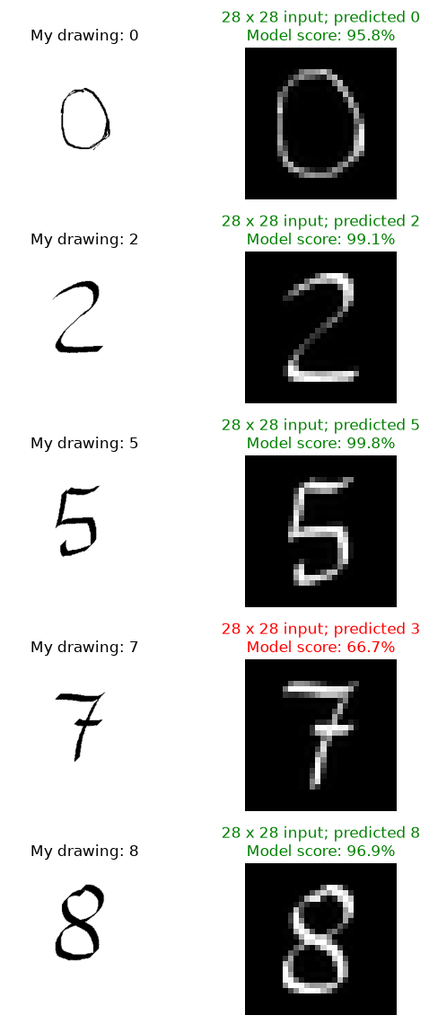

```
Correct on my five drawings: 4/5.
This is a small inference demonstration, not a reliable accuracy estimate.
The drawings were not used for training. We kept incorrect predictions too.
```

```python
# The filename supplies the known answer; the model sees only the image pixels.
# If you choose different digits, change this mapping to match your five files.
HANDWRITING_FILES = {
    "digit_0.png": 0,
    "digit_2.png": 2,
    "digit_5.png": 5,
    "digit_7.png": 7,
    "digit_8.png": 8,
}
missing = [name for name in HANDWRITING_FILES if not (HANDWRITING_DIR / name).is_file()]
if missing:
    print("Save your five Paint PNGs in:", HANDWRITING_DIR.resolve())
    print("Still missing:", ", ".join(missing))
    print("Then run this cell again. No handwriting predictions have been made yet.")
else:
    # Preserve the originals and display the exact inputs used for inference.
    results = []
    fig, axes = plt.subplots(len(HANDWRITING_FILES), 2, figsize=(6, 2.3 * len(HANDWRITING_FILES)), squeeze=False)
    for row, (filename, true_digit) in enumerate(HANDWRITING_FILES.items()):
        path = HANDWRITING_DIR / filename
        prepared, predicted, score = predict_handwriting(path)
        with Image.open(path) as original:
            axes[row, 0].imshow(original.convert("RGB"))
        axes[row, 0].set_title(f"My drawing: {true_digit}")
        axes[row, 1].imshow(prepared, cmap="gray", vmin=0, vmax=255)
        axes[row, 1].set_title(f"28 x 28 input; predicted {predicted}\nModel score: {score:.1%}",
                             color="green" if predicted == true_digit else "red")
        for ax in axes[row]:
            ax.axis("off")
        results.append({"image": filename, "true_digit": true_digit,
                        "predicted_digit": predicted, "model_score": score,
                        "correct": predicted == true_digit,
                        "source": "user drawing in Paint",
                        "checkpoint": "outputs/mnist/mnist_cnn.pth"})
    plt.tight_layout()
    results_dir = Path("outputs") / "mnist"
    results_dir.mkdir(parents=True, exist_ok=True)
    fig.savefig(results_dir / "my_handwriting_predictions.png", dpi=120)
    plt.show()
    correct = sum(item["correct"] for item in results)
    print(f"Correct on my five drawings: {correct}/{len(results)}.")
    print("This is a small inference demonstration, not a reliable accuracy estimate.")
    print("The drawings were not used for training. We kept incorrect predictions too.")
    (results_dir / "my_handwriting_results.json").write_text(json.dumps(results, indent=2), encoding="utf-8")
```

### 1.10 Problem 1 conclusions

The two-block MNIST model achieved 98.26% accuracy on the official 10,000-image test set. The selected checkpoint came from epoch 5, chosen using validation loss.

I drew five digits in Paint. The saved model correctly recognised 0, 2, 5 and 8, but classified my 7 as 3 (model score 66.7%). Thus, four of five personal examples were correct. The crossed stroke and shape of my 7 differ from many MNIST examples, which may contribute to the error; this small check does not establish its cause. The original and processed images are shown above, including the mistake.

These drawings were used only for inference. The weights were not changed, and no attempt was discarded to improve the reported result. Five examples cannot provide a reliable estimate of accuracy on personal handwriting. **Problem 1 is complete.**

## Problem 2: improve flower classification

Adapted from `2_pytorch_CNN_Classify_flowers.ipynb`.

The task is to classify photos as daisy, dandelion, roses, sunflowers or tulips.  
The course model has three convolutional blocks and two linear layers.  
We must add two convolutional blocks and one linear layer with ReLU, then document a small set of experiments.  
We will use no data augmentation.

The supplied notebook records 75.1% training accuracy at its final epoch and 65.34% test accuracy for the checkpoint selected by validation loss.  
These are different measures; the supplied results are reference results, not results from our own run.

We will keep the same data split across experiments, use validation results to choose settings and check for overfitting,  
and reserve the test set for final evaluation. Adding depth does not guarantee better accuracy.

**Progress:** Problem 2 is complete.  
Sections 2.13-2.17 document the controlled experiments, final selection and test results.

### 2.1 Load the flower photos

Unlike MNIST, these photos arrive in folders, one per flower class.  
`ImageFolder` reads the folder names and assigns integer labels in alphabetical order.

`Resize` makes every image 64 x 64 pixels; this can change its proportions.  
`ToTensor` converts it to a tensor and scales the pixel values to 0-1.  
`Compose` applies these operations in order. RGB photos have three channels, so each tensor has shape `(3, 64, 64)`.

The first run downloads an archive of about 220 MB into `data/`.  
Git ignores this folder. We will split this catalogue into training, validation and test sets in the next step.

```python
from pathlib import Path

import matplotlib.pyplot as plt
import torch
from torchvision import datasets, transforms
from torchvision.datasets.utils import download_and_extract_archive

# Separate names keep the flower data distinct from Problem 1's MNIST data.
FLOWER_DATA_DIR = Path("data")
FLOWER_IMAGE_SIZE = 64
flower_root = FLOWER_DATA_DIR / "flower_photos"

# Reuse the downloaded photos on later runs.
if not flower_root.exists():
    download_and_extract_archive(
        "https://storage.googleapis.com/download.tensorflow.org/example_images/flower_photos.tgz",
        download_root=str(FLOWER_DATA_DIR),
        md5="6f87fb78e9cc9ab41eff2015b380011d",
    )

# Resize to a common size and convert to tensors. No data augmentation.
flower_transform = transforms.Compose([
    transforms.Resize((FLOWER_IMAGE_SIZE, FLOWER_IMAGE_SIZE)),
    transforms.ToTensor(),
])
flower_catalog = datasets.ImageFolder(flower_root, transform=flower_transform)
flower_class_names = flower_catalog.classes
print(f"Images: {len(flower_catalog):,}")
print(f"Folder-to-label mapping: {flower_catalog.class_to_idx}")
flower_image, flower_label = flower_catalog[0]
print(f"One image: {tuple(flower_image.shape)}")
print(f"Label: {flower_label} ({flower_class_names[flower_label]})")
```

```
Images: 3,670
Folder-to-label mapping: {'daisy': 0, 'dandelion': 1, 'roses': 2, 'sunflowers': 3, 'tulips': 4}
One image: (3, 64, 64)
Label: 0 (daisy)
```

### 2.2 Inspect one photo per class

For MNIST, we removed the single channel dimension to plot a greyscale image. Here, all three colour channels are needed. `permute(1, 2, 0)` moves the channel dimension to the end, changing `(3, 64, 64)` into `(64, 64, 3)` for Matplotlib. It does not discard colour information.

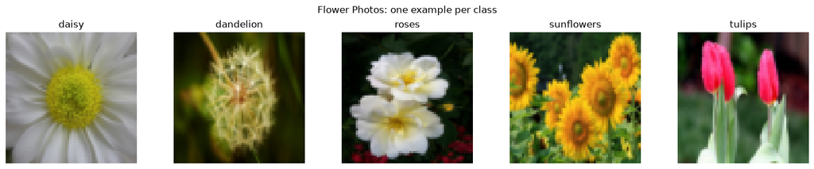

```python
# Show one example per class to check the images and folder labels.
fig, axes = plt.subplots(1, len(flower_class_names), figsize=(15, 3))
for label, ax in enumerate(axes):
    index = flower_catalog.targets.index(label)
    image, target = flower_catalog[index]
    # RGB plotting needs (height, width, channels), rather than (channels, height, width).
    ax.imshow(image.permute(1, 2, 0))
    ax.set_title(flower_class_names[target])
    ax.axis("off")
fig.suptitle("Flower Photos: one example per class")
plt.tight_layout()
plt.show()
```

### 2.3 Split the data

We use 70% of the photos for training, about 15% for validation and about 15% for testing. Whole images cannot be split, so the last two sets differ by one image.

- **Training:** updates the model weights.
- **Validation:** compares experiments and selects the saved weights.
- **Test:** evaluates the final selected model.

`train_test_split` divides image indices.  
`stratify` keeps approximately the same proportion of each flower class in each set.  
A fixed `random_state` makes the split repeatable.  
The second split uses the labels of the remaining images, in their current order.

`Subset` refers to selected examples in the existing catalogue; it does not copy image files.  
All three subsets therefore use the same resizing and tensor conversion. We will retain this split throughout our experiments.

```python
import numpy as np
from sklearn.model_selection import train_test_split
from torch.utils.data import Subset, DataLoader

FLOWER_SEED = 42
flower_indices = np.arange(len(flower_catalog))
flower_targets = np.asarray(flower_catalog.targets)

# Reserve 30% for validation and testing; use 70% for training.
flower_train_indices, flower_remaining_indices = train_test_split(
    flower_indices,
    test_size=0.30,
    random_state=FLOWER_SEED,
    stratify=flower_targets,
)

# Divide the reserved images equally between validation and testing.
flower_val_indices, flower_test_indices = train_test_split(
    flower_remaining_indices,
    test_size=0.50,
    random_state=FLOWER_SEED,
    stratify=flower_targets[flower_remaining_indices],
)

# Each Subset retrieves only its assigned images from the original catalogue.
flower_train_dataset = Subset(flower_catalog, flower_train_indices.tolist())
flower_val_dataset = Subset(flower_catalog, flower_val_indices.tolist())
flower_test_dataset = Subset(flower_catalog, flower_test_indices.tolist())

# Check that every image belongs to exactly one split.
flower_split_sets = [set(indices.tolist()) for indices in
                     (flower_train_indices, flower_val_indices, flower_test_indices)]
assert flower_split_sets[0].isdisjoint(flower_split_sets[1])
assert flower_split_sets[0].isdisjoint(flower_split_sets[2])
assert flower_split_sets[1].isdisjoint(flower_split_sets[2])
assert set.union(*flower_split_sets) == set(flower_indices.tolist())

for name, indices in [("Training", flower_train_indices),
                      ("Validation", flower_val_indices),
                      ("Test", flower_test_indices)]:
    counts = np.bincount(flower_targets[indices], minlength=len(flower_class_names))
    print(f"{name}: {len(indices):,} images")
    print(dict(zip(flower_class_names, counts.tolist())))
```

```
Training: 2,569 images
{'daisy': 443, 'dandelion': 629, 'roses': 449, 'sunflowers': 489, 'tulips': 559}
Validation: 550 images
{'daisy': 95, 'dandelion': 134, 'roses': 96, 'sunflowers': 105, 'tulips': 120}
Test: 551 images
{'daisy': 95, 'dandelion': 135, 'roses': 96, 'sunflowers': 105, 'tulips': 120}
```

### 2.4 Prepare batches

A `Dataset` supplies individual examples.  
A `DataLoader` groups them into batches.  
Here, a full batch contains 64 images and 64 labels.  
Its image tensor has shape `(64, 3, 64, 64)`: batch size, colour channels, height and width.

We shuffle only the training set.  
Validation and test examples keep a fixed order.  
`num_workers=0` loads images in the current process, which keeps this setup straightforward.  
The final batch may contain fewer than 64 images; the default keeps it.

The seeded generator controls training shuffles.  
Its state advances as batches are requested.  
When comparing models later, we will reset the model seed and training-loader generator for each run.  
The preview below uses a separate loader.

```python
FLOWER_BATCH_SIZE = 64

# Shuffle training examples into a new order on each pass through the data.
flower_train_loader = DataLoader(
    flower_train_dataset,
    batch_size=FLOWER_BATCH_SIZE,
    shuffle=True,
    generator=torch.Generator().manual_seed(FLOWER_SEED),
    num_workers=0,
)
flower_val_loader = DataLoader(
    flower_val_dataset, batch_size=FLOWER_BATCH_SIZE,
    shuffle=False, num_workers=0,
)
flower_test_loader = DataLoader(
    flower_test_dataset, batch_size=FLOWER_BATCH_SIZE,
    shuffle=False, num_workers=0,
)

# Use a separate loader for this preview so the training shuffle is untouched.
flower_preview_loader = DataLoader(
    flower_train_dataset, batch_size=FLOWER_BATCH_SIZE,
    shuffle=False, num_workers=0,
)
flower_batch_images, flower_batch_labels = next(iter(flower_preview_loader))
print(f"Image batch: {tuple(flower_batch_images.shape)}")
print(f"Label batch: {tuple(flower_batch_labels.shape)}")
print(f"Label type: {flower_batch_labels.dtype}")
print(f"Training batches per epoch: {len(flower_train_loader)}")
assert flower_batch_images.shape == (FLOWER_BATCH_SIZE, 3, FLOWER_IMAGE_SIZE, FLOWER_IMAGE_SIZE)
assert flower_batch_labels.dtype == torch.int64
```

```
Image batch: (64, 3, 64, 64)
Label batch: (64,)
Label type: torch.int64
Training batches per epoch: 41
```

**Next step:** build and train the course model as a baseline. Then add the required layers and compare a small number of experiments using the same validation set.

### 2.5 Build the baseline CNN

A baseline is the starting model against which we compare changes. This is the three-block CNN from the course, with its original layer sizes.

Each block contains a convolution, ReLU and max pooling. A convolution learns filters that respond to image patterns. ReLU replaces negative values with zero. Max pooling keeps the largest value in each 2 x 2 region, halving the height and width. Padding keeps the convolution itself from shrinking the image.

For one image, the shapes after each block are:

`(3, 64, 64) -> (16, 32, 32) -> (32, 16, 16) -> (64, 8, 8)`

`Flatten` turns the last feature maps into 4,096 values per image. A linear layer combines them into 64 values, ReLU follows, and the final linear layer produces five class scores. These scores are called logits. The batch dimension remains throughout.

`CrossEntropyLoss` compares the raw scores with the correct class labels. We do not add softmax to the model because this loss handles the needed conversion internally. Adam uses gradients to update the weights.

Run this cell again before repeating baseline training: it creates fresh weights and a fresh optimiser. The fixed seed helps repeat runs within the same environment; it does not guarantee identical results across devices or software versions.

```python
import copy
import json
import random
import time
from torch import nn

# Match the course baseline: 64 x 64 images, Adam, 0.001 learning rate, 15 epochs.
FLOWER_EPOCHS = 15
FLOWER_LEARNING_RATE = 0.001
flower_device = torch.device("cuda" if torch.cuda.is_available() else "cpu")
torch.set_num_threads(4)
random.seed(FLOWER_SEED)
np.random.seed(FLOWER_SEED)
torch.manual_seed(FLOWER_SEED)

class BaselineFlowerCNN(nn.Module):
    """The course model: three convolutional blocks and two linear layers."""

    def __init__(self, num_classes):
        super().__init__()
        self.features = nn.Sequential(
            # Block 1: (3, 64, 64) -> (16, 32, 32).
            nn.Conv2d(3, 16, kernel_size=3, padding=1),
            nn.ReLU(),
            nn.MaxPool2d(2),
            # Block 2: (16, 32, 32) -> (32, 16, 16).
            nn.Conv2d(16, 32, kernel_size=3, padding=1),
            nn.ReLU(),
            nn.MaxPool2d(2),
            # Block 3: (32, 16, 16) -> (64, 8, 8).
            nn.Conv2d(32, 64, kernel_size=3, padding=1),
            nn.ReLU(),
            nn.MaxPool2d(2),
        )
        self.classifier = nn.Sequential(
            nn.Flatten(),
            nn.Linear(64 * (FLOWER_IMAGE_SIZE // 8) ** 2, 64),
            nn.ReLU(),
            nn.Linear(64, num_classes),
        )

    def forward(self, images):
        features = self.features(images)
        return self.classifier(features)

flower_baseline = BaselineFlowerCNN(len(flower_class_names)).to(flower_device)
flower_criterion = nn.CrossEntropyLoss()
flower_optimizer = torch.optim.Adam(
    flower_baseline.parameters(), lr=FLOWER_LEARNING_RATE
)

print(f"Device: {flower_device}")
print(flower_baseline)
print(f"Trainable parameters: {sum(p.numel() for p in flower_baseline.parameters()):,}")
with torch.no_grad():
    flower_example_scores = flower_baseline(flower_batch_images.to(flower_device))
print(f"Output shape: {tuple(flower_example_scores.shape)}")
assert flower_example_scores.shape == (len(flower_batch_images), len(flower_class_names))
```

```
Device: cpu
BaselineFlowerCNN(
  (features): Sequential(
    (0): Conv2d(3, 16, kernel_size=(3, 3), stride=(1, 1), padding=(1, 1))
    (1): ReLU()
    (2): MaxPool2d(kernel_size=2, stride=2, padding=0, dilation=1, ceil_mode=False)
    (3): Conv2d(16, 32, kernel_size=(3, 3), stride=(1, 1), padding=(1, 1))
    (4): ReLU()
    (5): MaxPool2d(kernel_size=2, stride=2, padding=0, dilation=1, ceil_mode=False)
    (6): Conv2d(32, 64, kernel_size=(3, 3), stride=(1, 1), padding=(1, 1))
    (7): ReLU()
    (8): MaxPool2d(kernel_size=2, stride=2, padding=0, dilation=1, ceil_mode=False)
  )
  (classifier): Sequential(
    (0): Flatten(start_dim=1, end_dim=-1)
    (1): Linear(in_features=4096, out_features=64, bias=True)
    (2): ReLU()
    (3): Linear(in_features=64, out_features=5, bias=True)
  )
)
Trainable parameters: 286,117
Output shape: (64, 5)
```

### 2.6 Train and validate the baseline

An epoch is one complete pass through the training set. We use 15 epochs and a learning rate of 0.001, matching the course baseline.

The evaluation function measures loss and accuracy without changing weights. `model.eval()` selects evaluation behaviour; `torch.no_grad()` avoids recording calculations for backpropagation.

For each training batch we clear old gradients, calculate scores, measure loss, calculate gradients and update weights. At the end of each epoch, we evaluate on validation images. Training metrics are accumulated while weights change; validation metrics use the weights at the end of the epoch.

We retain a separate copy of the weights whenever validation loss improves. After all 15 epochs, we restore the best copy. This is checkpoint selection, not early stopping: every epoch still runs. We do not use the test loader here.

```python
def evaluate_flower_model(model, loader):
    """Measure average loss and accuracy without updating model weights."""
    model.eval()
    loss_sum = 0.0
    correct = 0
    count = 0
    with torch.no_grad():
        for images, labels in loader:
            images = images.to(flower_device)
            labels = labels.to(flower_device)
            scores = model(images)
            loss = flower_criterion(scores, labels)
            # Weight each batch by its size; the last batch can be smaller.
            loss_sum += loss.item() * len(labels)
            correct += (scores.argmax(dim=1) == labels).sum().item()
            count += len(labels)
    return loss_sum / count, correct / count
```

```python
# Recreate the loader so earlier notebook activity does not change its shuffle.
flower_train_loader = DataLoader(
    flower_train_dataset, batch_size=FLOWER_BATCH_SIZE, shuffle=True,
    generator=torch.Generator().manual_seed(FLOWER_SEED), num_workers=0,
)
flower_baseline_history = {
    "train_loss": [], "val_loss": [],
    "train_accuracy": [], "val_accuracy": [],
}
flower_best_val_loss = float("inf")
flower_best_state = None
flower_best_epoch = 0
flower_start_time = time.perf_counter()

for epoch in range(1, FLOWER_EPOCHS + 1):
    flower_baseline.train()
    loss_sum = 0.0
    correct = 0
    count = 0
    for images, labels in flower_train_loader:
        images = images.to(flower_device)
        labels = labels.to(flower_device)
        flower_optimizer.zero_grad()                 # Clear previous gradients.
        scores = flower_baseline(images)             # Calculate class scores.
        loss = flower_criterion(scores, labels)       # Measure prediction error.
        loss.backward()                              # Calculate gradients.
        flower_optimizer.step()                      # Update model weights.
        loss_sum += loss.item() * len(labels)
        correct += (scores.argmax(dim=1) == labels).sum().item()
        count += len(labels)

    train_loss = loss_sum / count
    train_accuracy = correct / count
    val_loss, val_accuracy = evaluate_flower_model(flower_baseline, flower_val_loader)
    flower_baseline_history["train_loss"].append(train_loss)
    flower_baseline_history["train_accuracy"].append(train_accuracy)
    flower_baseline_history["val_loss"].append(val_loss)
    flower_baseline_history["val_accuracy"].append(val_accuracy)

    if val_loss < flower_best_val_loss:
        flower_best_val_loss = val_loss
        flower_best_epoch = epoch
        # Copy the weights so later training does not change this saved state.
        flower_best_state = copy.deepcopy(flower_baseline.state_dict())

    print(f"Epoch {epoch:02d}/{FLOWER_EPOCHS} | "
          f"train loss {train_loss:.3f}, accuracy {train_accuracy:.1%} | "
          f"validation loss {val_loss:.3f}, accuracy {val_accuracy:.1%}", flush=True)

flower_training_seconds = time.perf_counter() - flower_start_time
flower_baseline.load_state_dict(flower_best_state)
flower_baseline.eval()
flower_selected_val_loss, flower_selected_val_accuracy = evaluate_flower_model(
    flower_baseline, flower_val_loader
)
assert abs(flower_selected_val_loss - flower_best_val_loss) < 1e-6
print(f"Restored epoch {flower_best_epoch}, chosen by lowest validation loss.")
print(f"Selected validation accuracy: {flower_selected_val_accuracy:.2%}")
print(f"Training time: {flower_training_seconds / 60:.1f} minutes")
```

```
Restored epoch 11, chosen by lowest validation loss.
Selected validation accuracy: 64.18%
Training time: 2.1 minutes
```

[output not shown]

### 2.7 Inspect learning curves and save the baseline

Lower loss and higher accuracy indicate improvement. If training improves while validation loss rises, that suggests overfitting. The dashed line marks the epoch selected by validation loss, which need not have the highest validation accuracy.

We save the selected weights, validation results and data split. A reload check verifies that the saved weights reproduce the same scores on a training batch. Test results remain pending until we have compared the planned experiments.

The deeper model required by the assignment will be a separate experiment: five convolutional blocks and three linear layers, with ReLU after the additional hidden linear layer.

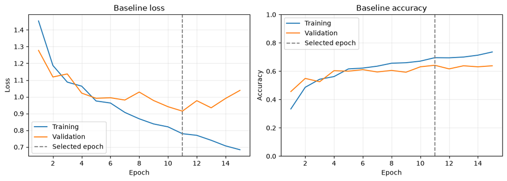

```
Saved baseline weights to outputs\flowers\baseline_cnn.pth; reload verified.
Saved validation results and the exact data split. Test evaluation remains pending.
```

```python
flower_epochs = np.arange(1, FLOWER_EPOCHS + 1)
fig, axes = plt.subplots(1, 2, figsize=(11, 4))
for ax, metric in zip(axes, ["loss", "accuracy"]):
    ax.plot(flower_epochs, flower_baseline_history["train_" + metric], label="Training")
    ax.plot(flower_epochs, flower_baseline_history["val_" + metric], label="Validation")
    ax.axvline(flower_best_epoch, color="gray", linestyle="--", label="Selected epoch")
    ax.set(xlabel="Epoch", ylabel=metric.capitalize(), title="Baseline " + metric)
    ax.legend()
    ax.grid(alpha=0.25)
axes[1].set_ylim(0, 1)
plt.tight_layout()
plt.show()

flower_output_dir = Path("outputs") / "flowers"
flower_output_dir.mkdir(parents=True, exist_ok=True)
flower_baseline_path = flower_output_dir / "baseline_cnn.pth"
torch.save({
    "state_dict": {k: v.detach().cpu() for k, v in flower_baseline.state_dict().items()},
    "architecture": "BaselineFlowerCNN",
    "class_names": flower_class_names,
    "image_size": FLOWER_IMAGE_SIZE,
    "seed": FLOWER_SEED,
    "best_epoch": flower_best_epoch,
}, flower_baseline_path)

# Check that saving and reloading preserves the model's scores.
flower_checkpoint = torch.load(flower_baseline_path, map_location=flower_device, weights_only=True)
flower_reloaded_baseline = BaselineFlowerCNN(len(flower_class_names)).to(flower_device)
flower_reloaded_baseline.load_state_dict(flower_checkpoint["state_dict"])
flower_reloaded_baseline.eval()
with torch.no_grad():
    flower_check_batch = flower_batch_images.to(flower_device)
    torch.testing.assert_close(
        flower_baseline(flower_check_batch), flower_reloaded_baseline(flower_check_batch)
    )

flower_baseline_metrics = {
    "experiment": "course_baseline",
    "architecture": "BaselineFlowerCNN",
    "epochs": FLOWER_EPOCHS,
    "learning_rate": FLOWER_LEARNING_RATE,
    "batch_size": FLOWER_BATCH_SIZE,
    "image_size": FLOWER_IMAGE_SIZE,
    "seed": FLOWER_SEED,
    "device": str(flower_device),
    "pytorch_version": str(torch.__version__),
    "best_epoch": flower_best_epoch,
    "selected_validation_loss": flower_selected_val_loss,
    "selected_validation_accuracy": flower_selected_val_accuracy,
    "training_seconds": flower_training_seconds,
    "history": flower_baseline_history,
    "test_evaluated": False,
}
(flower_output_dir / "baseline_metrics.json").write_text(
    json.dumps(flower_baseline_metrics, indent=2), encoding="utf-8"
)
# Keep the exact split and class mapping for later experiments and visualisations.
flower_split_manifest = {
    "seed": FLOWER_SEED,
    "class_to_idx": flower_catalog.class_to_idx,
    "splits": {
        name: [Path(flower_catalog.samples[int(i)][0]).relative_to(flower_root).as_posix()
               for i in indices]
        for name, indices in [("train", flower_train_indices),
                              ("validation", flower_val_indices),
                              ("test", flower_test_indices)]
    },
}
(flower_output_dir / "split_manifest.json").write_text(
    json.dumps(flower_split_manifest, indent=2), encoding="utf-8"
)
print(f"Saved baseline weights to {flower_baseline_path}; reload verified.")
print("Saved validation results and the exact data split. Test evaluation remains pending.")
```

### Baseline findings

This run used the CPU and completed 15 epochs in about 2.1 minutes in the latest saved run.  
The model has 286,117 trainable parameters.

| Measure | Result |
| --- | --- |
| Epoch selected by lowest validation loss | 11 |
| Selected validation loss | 0.9146 |
| Selected validation accuracy | 64.18% |
| Final-epoch training accuracy | 73.57% |
| Final-epoch validation accuracy | 63.82% |

Training accuracy improved after epoch 11, but validation loss increased.  
This suggests overfitting and supports retaining the earlier checkpoint.  
A higher training score alone does not establish that a change helps on unseen images.

These are results from our run, rather than from the course notebook.  
Differences from the course results can arise from the device, software versions and numerical calculations.  
We will compare our later experiments with this baseline using the same split and evaluation method.  
The test set has not been evaluated.

**Next step:** we will add two convolutional blocks and one hidden linear layer with ReLU.  
And keep the initial comparison small and record whether the deeper model improves validation performance.  
Greater depth does not guarantee improvement.

### 2.8 Understand the baseline curves

At epoch 15, training loss is about 0.684 and validation loss about 1.038. Training accuracy is 73.57%,  
while validation accuracy is 63.82% (351 of 550 validation images).  
Accuracy counts correct top-scoring classes.  
Cross-entropy loss also accounts for the score assigned to the correct class; confident errors incur a larger penalty.  
Loss is not a percentage and can exceed one.

Validation loss reaches its minimum at epoch 11.  
Later training lowers training loss but does not lower validation loss, suggesting overfitting.  
We keep epoch 11's weights, whose validation accuracy is 64.18% (353 of 550 images).  
Training accuracy is measured while weights change within an epoch; validation accuracy uses the fixed weights at its end.

Adding layers may help the model learn useful patterns, but it can also make training harder or increase overfitting.  
We need an experiment to find out.

### 2.9 Build the required deeper model

A convolutional block here means `Conv2d -> ReLU -> MaxPool2d`.  
Convolution learns weighted combinations of nearby values across the input channels. Each output channel is a feature map.  
ReLU replaces negative values with zero.  
Pooling reduces each feature map's height and width. Later blocks process the feature maps produced by earlier blocks.

We retain the first three blocks' structure and add two blocks.  
This is a new model with fresh weights; it does not reuse the trained baseline weights.

| Stage | Baseline: shape per image | Deeper model: shape per image |
| --- | --- | --- |
| Input | 3 x 64 x 64 | 3 x 64 x 64 |
| Block 1 | 16 x 32 x 32 | 16 x 32 x 32 |
| Block 2 | 32 x 16 x 16 | 32 x 16 x 16 |
| Block 3 | 64 x 8 x 8 | 64 x 8 x 8 |
| New block 4 | — | 128 x 4 x 4 |
| New block 5 | — | 256 x 2 x 2 |
| Flatten | 4,096 | 1,024 |
| Hidden linear layer + ReLU | 64 | 64 |
| New hidden linear layer + ReLU | — | 32 |
| Output linear layer | 5 | 5 |

A linear layer computes weighted sums of its inputs and adds learned biases.  
The new `Linear(64, 32)` produces 32 values from 64 inputs. Its ReLU lets the classifier learn nonlinear relationships.  
Two linear layers in succession without an intervening nonlinear activation are equivalent to a single affine transformation.

Five pooling stages reduce 64 x 64 to 2 x 2.  
The first linear layer must therefore accept `256 * 2 * 2 = 1024` inputs, rather than the baseline's 4096.  
The final layer still produces five raw scores; there is no ReLU or softmax after it.  
We keep the 3 x 3 kernels, max pooling and ReLU for this first deeper-model comparison.

```python
import torch
from torch import nn

class DeeperFlowerCNN(nn.Module):
    """Five convolutional blocks and three linear layers for 64 x 64 RGB images."""

    def __init__(self, num_classes=5):
        super().__init__()
        self.features = nn.Sequential(
            # Block 1: three colour channels -> 16 feature maps.
            nn.Conv2d(3, 16, kernel_size=3, padding=1),
            nn.ReLU(),
            nn.MaxPool2d(2),                       # 64 x 64 -> 32 x 32
            # Block 2.
            nn.Conv2d(16, 32, kernel_size=3, padding=1),
            nn.ReLU(),
            nn.MaxPool2d(2),                       # 32 x 32 -> 16 x 16
            # Block 3: the last block in the original model.
            nn.Conv2d(32, 64, kernel_size=3, padding=1),
            nn.ReLU(),
            nn.MaxPool2d(2),                       # 16 x 16 -> 8 x 8
            # NEW block 4.
            nn.Conv2d(64, 128, kernel_size=3, padding=1),
            nn.ReLU(),
            nn.MaxPool2d(2),                       # 8 x 8 -> 4 x 4
            # NEW block 5.
            nn.Conv2d(128, 256, kernel_size=3, padding=1),
            nn.ReLU(),
            nn.MaxPool2d(2),                       # 4 x 4 -> 2 x 2
        )
        self.classifier = nn.Sequential(
            nn.Flatten(),                         # 256 * 2 * 2 = 1,024 values
            nn.Linear(256 * 2 * 2, 64),
            nn.ReLU(),
            nn.Linear(64, 32),                     # NEW hidden linear layer
            nn.ReLU(),                            # Required activation after it
            nn.Linear(32, num_classes),           # Five raw class scores
        )

    def forward(self, images):
        features = self.features(images)
        return self.classifier(features)
```

### 2.10 Check the deeper model before training

The following cell passes a batch through every stage and prints its shape.  
It checks that we have exactly five convolutional layers, three linear layers and five finite output scores per image.  
These are structural checks, not a test of classification accuracy.  
The test dataset is not used.

The model definition also lives in `05_deeper_flower_model.py` for reuse.  
The next step is to train this model with the same split, batch size, learning rate and epoch budget as the baseline, then compare validation results.

```python
# Fresh weights: this model has not been trained yet.
torch.manual_seed(FLOWER_SEED)
flower_device = torch.device("cuda" if torch.cuda.is_available() else "cpu")
flower_deeper = DeeperFlowerCNN(len(flower_class_names)).to(flower_device)

# Follow an actual training batch through the model, without changing weights.
flower_deeper.eval()
with torch.no_grad():
    values = flower_batch_images.to(flower_device)
    print(f"Input: {tuple(values.shape)}")
    for layer_number, layer in enumerate(flower_deeper.features, start=1):
        values = layer(values)
        if isinstance(layer, nn.MaxPool2d):
            print(f"After block {layer_number // 3}: {tuple(values.shape)}")
    for layer in flower_deeper.classifier:
        values = layer(values)
        print(f"After {type(layer).__name__}: {tuple(values.shape)}")
    torch.testing.assert_close(values, flower_deeper(flower_batch_images.to(flower_device)))

assert values.shape == (len(flower_batch_images), len(flower_class_names))
assert torch.isfinite(values).all()
assert sum(isinstance(layer, nn.Conv2d) for layer in flower_deeper.modules()) == 5
assert sum(isinstance(layer, nn.Linear) for layer in flower_deeper.modules()) == 3
print(f"Trainable parameters: {sum(p.numel() for p in flower_deeper.parameters()):,}")
print("Architecture checks passed. These weights are untrained; no accuracy result yet.")
```

```
Input: (64, 3, 64, 64)
After block 1: (64, 16, 32, 32)
After block 2: (64, 32, 16, 16)
After block 3: (64, 64, 8, 8)
After block 4: (64, 128, 4, 4)
After block 5: (64, 256, 2, 2)
After Flatten: (64, 1024)
After Linear: (64, 64)
After ReLU: (64, 64)
After Linear: (64, 32)
After ReLU: (64, 32)
After Linear: (64, 5)
Trainable parameters: 460,453
Architecture checks passed. These weights are untrained; no accuracy result yet.
```

### 2.11 Train the deeper model: first experiment

We now test whether the required deeper architecture helps under the baseline settings: 64 x 64 images, batches of 64,  
Adam with learning rate 0.001, and 15 epochs.  
We use the same image split and reset the seed and training-loader generator. No data augmentation is used.

Only the architecture changes.  
Its extra blocks also change the number and spatial size of the final feature maps, so this compares the complete architecture change rather than isolating depth alone.  
The new model starts with fresh weights; it does not continue training the baseline.

Run the setup cell below before repeating this training experiment.  
We reuse `evaluate_flower_model` from Section 2.6. The lowest validation loss selects the saved epoch.  
All 15 epochs run, and no test-set score is used to guide this experiment.

```python
# Reset the experiment so rerunning this cell starts from fresh weights.
import copy
import json
import random
import time

FLOWER_EPOCHS = 15
FLOWER_LEARNING_RATE = 0.001
torch.set_num_threads(4)
random.seed(FLOWER_SEED)
np.random.seed(FLOWER_SEED)
torch.manual_seed(FLOWER_SEED)
flower_device = torch.device("cuda" if torch.cuda.is_available() else "cpu")
flower_deeper = DeeperFlowerCNN(len(flower_class_names)).to(flower_device)
flower_criterion = nn.CrossEntropyLoss()
flower_deeper_optimizer = torch.optim.Adam(
    flower_deeper.parameters(), lr=FLOWER_LEARNING_RATE
)

# Check that the saved baseline used these same experiment settings and split.
flower_output_dir = Path("outputs") / "flowers"
flower_reference_metrics = json.loads((flower_output_dir / "baseline_metrics.json").read_text())
for key, value in [("epochs", FLOWER_EPOCHS), ("learning_rate", FLOWER_LEARNING_RATE),
                   ("batch_size", FLOWER_BATCH_SIZE), ("image_size", FLOWER_IMAGE_SIZE),
                   ("seed", FLOWER_SEED)]:
    assert flower_reference_metrics[key] == value, f"Baseline setting differs: {key}"
flower_saved_split = json.loads((flower_output_dir / "split_manifest.json").read_text())
assert flower_saved_split["class_to_idx"] == flower_catalog.class_to_idx
for name, indices in [("train", flower_train_indices),
                      ("validation", flower_val_indices), ("test", flower_test_indices)]:
    paths = [Path(flower_catalog.samples[int(i)][0]).relative_to(flower_root).as_posix()
             for i in indices]
    assert paths == flower_saved_split["splits"][name], f"Different split: {name}"
print("Baseline settings and exact image split verified. Starting a fresh deeper model.")
```

```
Baseline settings and exact image split verified. Starting a fresh deeper model.
```

```python
# Recreate the loader so earlier notebook activity does not change its shuffle.
flower_train_loader = DataLoader(
    flower_train_dataset, batch_size=FLOWER_BATCH_SIZE, shuffle=True,
    generator=torch.Generator().manual_seed(FLOWER_SEED), num_workers=0,
)
flower_deeper_history = {
    "train_loss": [], "val_loss": [],
    "train_accuracy": [], "val_accuracy": [],
}
flower_deeper_best_val_loss = float("inf")
flower_deeper_best_state = None
flower_deeper_best_epoch = 0
flower_deeper_start_time = time.perf_counter()

for epoch in range(1, FLOWER_EPOCHS + 1):
    flower_deeper.train()
    loss_sum = 0.0
    correct = 0
    count = 0
    for images, labels in flower_train_loader:
        images = images.to(flower_device)
        labels = labels.to(flower_device)
        flower_deeper_optimizer.zero_grad()                 # Clear previous gradients.
        scores = flower_deeper(images)             # Calculate class scores.
        loss = flower_criterion(scores, labels)       # Measure prediction error.
        loss.backward()                              # Calculate gradients.
        flower_deeper_optimizer.step()                      # Update model weights.
        loss_sum += loss.item() * len(labels)
        correct += (scores.argmax(dim=1) == labels).sum().item()
        count += len(labels)

    train_loss = loss_sum / count
    train_accuracy = correct / count
    val_loss, val_accuracy = evaluate_flower_model(flower_deeper, flower_val_loader)
    flower_deeper_history["train_loss"].append(train_loss)
    flower_deeper_history["train_accuracy"].append(train_accuracy)
    flower_deeper_history["val_loss"].append(val_loss)
    flower_deeper_history["val_accuracy"].append(val_accuracy)

    if val_loss < flower_deeper_best_val_loss:
        flower_deeper_best_val_loss = val_loss
        flower_deeper_best_epoch = epoch
        # Copy the weights so later training does not change this saved state.
        flower_deeper_best_state = copy.deepcopy(flower_deeper.state_dict())

    print(f"Epoch {epoch:02d}/{FLOWER_EPOCHS} | "
          f"train loss {train_loss:.3f}, accuracy {train_accuracy:.1%} | "
          f"validation loss {val_loss:.3f}, accuracy {val_accuracy:.1%}", flush=True)

flower_deeper_training_seconds = time.perf_counter() - flower_deeper_start_time
flower_deeper.load_state_dict(flower_deeper_best_state)
flower_deeper.eval()
flower_deeper_selected_val_loss, flower_deeper_selected_val_accuracy = evaluate_flower_model(
    flower_deeper, flower_val_loader
)
assert abs(flower_deeper_selected_val_loss - flower_deeper_best_val_loss) < 1e-6
print(f"Restored epoch {flower_deeper_best_epoch}, chosen by lowest validation loss.")
print(f"Selected validation accuracy: {flower_deeper_selected_val_accuracy:.2%}")
print(f"Training time: {flower_deeper_training_seconds / 60:.1f} minutes")
```

```
Restored epoch 13, chosen by lowest validation loss.
Selected validation accuracy: 64.73%
Training time: 2.3 minutes
```

[output not shown]

### 2.12 Compare the baseline and deeper model

Compare validation metrics from each model's selected checkpoint.  
An accuracy change is reported in percentage points: for example, moving from 60% to 65% is a gain of 5 percentage points.

We plot both training and validation histories to look for overfitting.  
A deeper model is not automatically better.  
This is one run per architecture with one fixed seed, therefore a small difference should not be treated as proof of a general advantage.  
We save the deeper weights separately and check that reloading preserves its scores.

```
Deeper weights saved and reload verified.
Model         Epoch   Val loss   Val accuracy
Baseline         11     0.9146         64.18%
Deeper           13     0.9058         64.73%
Validation accuracy change: +0.55 percentage points
```

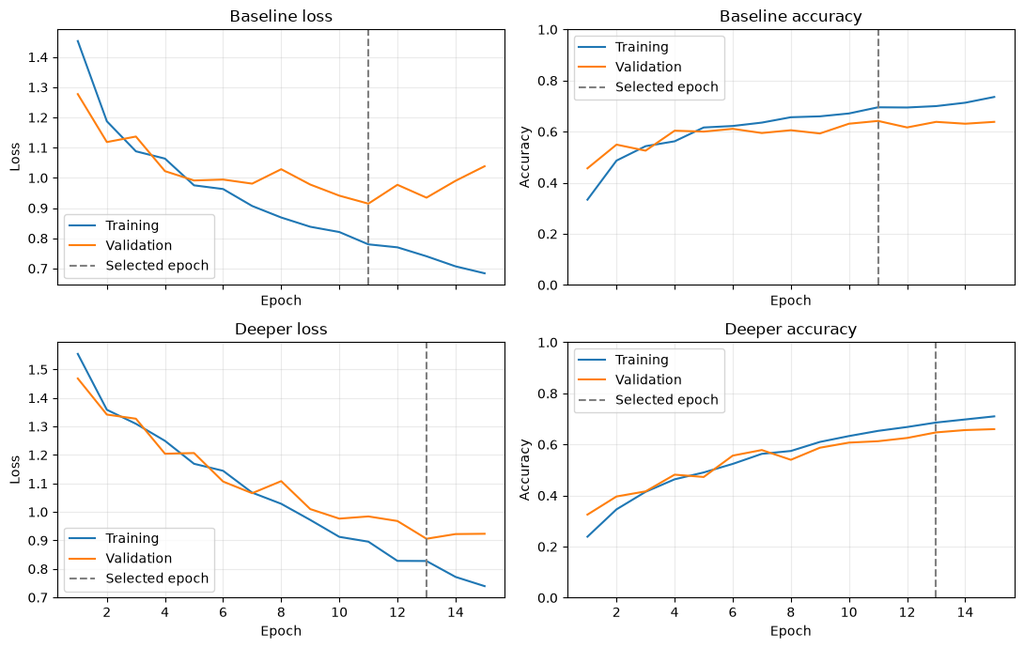

```
Test evaluation remains pending while we compare experiments.
```

```python
# Save the selected deeper checkpoint separately from the baseline.
flower_deeper_path = flower_output_dir / "deeper_cnn.pth"
torch.save({
    "state_dict": {k: v.detach().cpu() for k, v in flower_deeper.state_dict().items()},
    "architecture": "DeeperFlowerCNN",
    "class_names": flower_class_names,
    "image_size": FLOWER_IMAGE_SIZE,
    "seed": FLOWER_SEED,
    "best_epoch": flower_deeper_best_epoch,
}, flower_deeper_path)
flower_deeper_checkpoint = torch.load(flower_deeper_path, map_location=flower_device, weights_only=True)
flower_reloaded_deeper = DeeperFlowerCNN(len(flower_class_names)).to(flower_device)
flower_reloaded_deeper.load_state_dict(flower_deeper_checkpoint["state_dict"])
flower_reloaded_deeper.eval()
with torch.no_grad():
    check_images = flower_batch_images.to(flower_device)
    torch.testing.assert_close(flower_deeper(check_images), flower_reloaded_deeper(check_images))

flower_deeper_metrics = {
    "experiment": "deeper_same_settings",
    "architecture": "DeeperFlowerCNN",
    "epochs": FLOWER_EPOCHS,
    "learning_rate": FLOWER_LEARNING_RATE,
    "batch_size": FLOWER_BATCH_SIZE,
    "image_size": FLOWER_IMAGE_SIZE,
    "seed": FLOWER_SEED,
    "device": str(flower_device),
    "pytorch_version": str(torch.__version__),
    "best_epoch": flower_deeper_best_epoch,
    "selected_validation_loss": flower_deeper_selected_val_loss,
    "selected_validation_accuracy": flower_deeper_selected_val_accuracy,
    "training_seconds": flower_deeper_training_seconds,
    "history": flower_deeper_history,
    "test_evaluated": False,
}
(flower_output_dir / "deeper_metrics.json").write_text(
    json.dumps(flower_deeper_metrics, indent=2), encoding="utf-8"
)
print("Deeper weights saved and reload verified.")
print(f"{'Model':<12} {'Epoch':>6} {'Val loss':>10} {'Val accuracy':>14}")
for name, metrics in [("Baseline", flower_reference_metrics), ("Deeper", flower_deeper_metrics)]:
    print(f"{name:<12} {metrics['best_epoch']:>6} "
          f"{metrics['selected_validation_loss']:>10.4f} "
          f"{metrics['selected_validation_accuracy']:>14.2%}")
flower_accuracy_change = (flower_deeper_selected_val_accuracy
                          - flower_reference_metrics["selected_validation_accuracy"]) * 100
print(f"Validation accuracy change: {flower_accuracy_change:+.2f} percentage points")

# Show each run's training and validation curves, marking its selected epoch.
fig, axes = plt.subplots(2, 2, figsize=(11, 7), sharex=True)
for row, (name, metrics) in enumerate([("Baseline", flower_reference_metrics),
                                      ("Deeper", flower_deeper_metrics)]):
    epochs = np.arange(1, metrics["epochs"] + 1)
    for col, metric in enumerate(["loss", "accuracy"]):
        ax = axes[row, col]
        ax.plot(epochs, metrics["history"]["train_" + metric], label="Training")
        ax.plot(epochs, metrics["history"]["val_" + metric], label="Validation")
        ax.axvline(metrics["best_epoch"], color="gray", linestyle="--", label="Selected epoch")
        ax.set(xlabel="Epoch", ylabel=metric.capitalize(), title=name + " " + metric)
        ax.legend()
        ax.grid(alpha=0.25)
    axes[row, 1].set_ylim(0, 1)
plt.tight_layout()
fig.savefig(flower_output_dir / "baseline_vs_deeper.png", dpi=120)
plt.show()
print("Test evaluation remains pending while we compare experiments.")
```

### First deeper-model experiment: findings

| Model | Selected epoch | Validation loss | Validation accuracy |
| --- | --- | --- | --- |
| Baseline | 11 | 0.9146 | 64.18% |
| Deeper | 13 | 0.9058 | 64.73% |

The deeper model's selected checkpoint correctly classified 356 of 550 validation images, compared with 353 for the baseline: a gain of 0.55 percentage points.  
Its validation loss was also slightly lower.  
This is a small improvement from one run per model with a fixed seed, and is not evidence that adding depth will always help.

The final epoch reached 66.00% validation accuracy, but its loss (0.9233) exceeded the epoch-13 minimum.  
We selected checkpoints by validation loss before running this experiment, so we retain epoch 13.  
Accuracy counts correct top-scoring classes; loss also reflects how much probability the model assigns to the true labels.  
These measures need not improve together.

Training loss continued to fall after the selected epoch while validation loss rose slightly.  
This suggests some overfitting, although both selected checkpoints are fairly close in performance.  
The deeper run took about 1.7 minutes on the CPU.  
Both saved checkpoints have passed a reload check.

**Next suggested step:**  
make a small number of controlled changes to the deeper model's settings,  
document their effects on validation results and then evaluate the chosen model on the test set.  
The test set remains unused so problem 2 is not yet complete.

### 2.13 Plan four controlled experiments

We test four changes separately against the deeper reference.  
All retain five convolutional blocks, three linear layers and ReLU after the extra hidden linear layer.  
We keep 64 x 64 images, the same split, batches of 64 and 15 epochs, with Adam, seed 42 and no augmentation.

| Experiment | One change | Reason to test it |
| --- | --- | --- |
| Lower learning rate | 0.001 to 0.0005 | Smaller updates may improve optimisation, but can slow learning within 15 epochs. |
| LeakyReLU | Replace ReLU only in convolutional blocks; slope 0.01 for negative inputs | Allows a small gradient for negative activations. Classifier ReLUs remain. |
| Larger first kernel | First convolution: 3 x 3 to 5 x 5, padding 1 to 2 | Tests a larger local image region while preserving its output size. Other kernels remain 3 x 3. |
| Average pooling | Replace max pooling only in blocks 4 and 5 | Tests averaging local responses instead of retaining their maximum. |

Each trial starts from fresh weights and resets the training shuffle.  
A fixed seed does not make differently shaped weights identical.  
This is a small exploratory comparison, not a statistical study.  
We select checkpoints and the final five-block model by lowest validation loss. We will not change settings after inspecting test results.

```python
# Each configuration changes one setting relative to the first deeper model.
FLOWER_DEFAULT_CONFIG = {
    "learning_rate": 0.001, "activation": "relu",
    "first_kernel": 3, "last_pooling": "max",
}
FLOWER_EXPERIMENTS = [
    ("lower_learning_rate", {**FLOWER_DEFAULT_CONFIG, "learning_rate": 0.0005}),
    ("leaky_relu", {**FLOWER_DEFAULT_CONFIG, "activation": "leaky_relu"}),
    ("first_kernel_5", {**FLOWER_DEFAULT_CONFIG, "first_kernel": 5}),
    ("last_average_pooling", {**FLOWER_DEFAULT_CONFIG, "last_pooling": "average"}),
]

def build_flower_variant(config, num_classes):
    """Rebuild an experiment's exact architecture, including for later inference."""
    model = DeeperFlowerCNN(num_classes)
    if config["first_kernel"] == 5:
        # Padding of two keeps the first convolution's height and width unchanged.
        model.features[0] = nn.Conv2d(3, 16, kernel_size=5, padding=2)
    if config["activation"] == "leaky_relu":
        # Keep ReLU in the classifier, including after the required extra linear layer.
        for index in (1, 4, 7, 10, 13):
            model.features[index] = nn.LeakyReLU(negative_slope=0.01)
    if config["last_pooling"] == "average":
        for index in (11, 14):
            model.features[index] = nn.AvgPool2d(2)
    return model
```

### 2.14 Train each trial and keep its best checkpoint

The helper below repeats the same training procedure for each configuration.  
`config` records the settings needed to rebuild that model later. Every epoch is saved in the metrics file; the notebook prints only epochs 1, 5, 10 and 15 plus the selected result.  
Training may take several minutes on the CPU.

A deep copy preserves the best weights in memory.  
At the end of each trial, we restore that copy, save it to a separate file, rebuild the model from its configuration and verify the reloaded scores.  
No test images are used here.

```python
def measure_flower_model(model, loader, criterion, device):
    """Return per-image mean loss and accuracy with no parameter updates."""
    model.eval()
    total_loss, correct, count = 0.0, 0, 0
    with torch.no_grad():
        for images, labels in loader:
            images, labels = images.to(device), labels.to(device)
            scores = model(images)
            total_loss += criterion(scores, labels).item() * len(labels)
            correct += (scores.argmax(1) == labels).sum().item()
            count += len(labels)
    return total_loss / count, correct / count


def run_flower_experiment(name, config):
    """Train a fresh variant using only training and validation data."""
    random.seed(FLOWER_SEED)
    np.random.seed(FLOWER_SEED)
    torch.manual_seed(FLOWER_SEED)
    model = build_flower_variant(config, len(flower_class_names)).to(flower_device)
    criterion = nn.CrossEntropyLoss()
    optimizer = torch.optim.Adam(model.parameters(), lr=config["learning_rate"])
    loader = DataLoader(
        flower_train_dataset, batch_size=FLOWER_BATCH_SIZE, shuffle=True,
        generator=torch.Generator().manual_seed(FLOWER_SEED), num_workers=0,
    )
    history = {key: [] for key in ("train_loss", "val_loss", "train_accuracy", "val_accuracy")}
    best_loss, best_epoch, best_state = float("inf"), 0, None
    started = time.perf_counter()
    for epoch in range(1, FLOWER_EPOCHS + 1):
        model.train()
        total_loss, correct, count = 0.0, 0, 0
        for images, labels in loader:
            images, labels = images.to(flower_device), labels.to(flower_device)
            optimizer.zero_grad()
            scores = model(images)
            loss = criterion(scores, labels)
            loss.backward()
            optimizer.step()
            total_loss += loss.item() * len(labels)
            correct += (scores.argmax(1) == labels).sum().item()
            count += len(labels)
        val_loss, val_accuracy = measure_flower_model(model, flower_val_loader, criterion, flower_device)
        for key, value in [("train_loss", total_loss / count), ("train_accuracy", correct / count),
                           ("val_loss", val_loss), ("val_accuracy", val_accuracy)]:
            history[key].append(value)
        if val_loss < best_loss:
            best_loss, best_epoch = val_loss, epoch
            best_state = copy.deepcopy(model.state_dict())
        # Keep notebook output short while retaining every epoch in the saved history.
        if epoch == 1 or epoch % 5 == 0:
            print(f"{name}: epoch {epoch:02d}/{FLOWER_EPOCHS} | "
                  f"train {correct / count:.1%} | val {val_accuracy:.1%} | "
                  f"val loss {val_loss:.4f}", flush=True)
    elapsed = time.perf_counter() - started
    model.load_state_dict(best_state)
    model.eval()
    selected_loss, selected_accuracy = measure_flower_model(model, flower_val_loader, criterion, flower_device)
    assert abs(selected_loss - best_loss) < 1e-6
    checkpoint_path = flower_output_dir / (name + ".pth")
    torch.save({
        "state_dict": {k: v.detach().cpu() for k, v in model.state_dict().items()},
        "architecture": "DeeperFlowerCNN_variant", "config": config,
        "class_names": flower_class_names, "image_size": FLOWER_IMAGE_SIZE,
        "seed": FLOWER_SEED, "best_epoch": best_epoch,
    }, checkpoint_path)
    # Verify that the configuration rebuilds the saved model correctly.
    checkpoint = torch.load(checkpoint_path, map_location=flower_device, weights_only=True)
    reloaded = build_flower_variant(checkpoint["config"], len(checkpoint["class_names"])).to(flower_device)
    reloaded.load_state_dict(checkpoint["state_dict"])
    reloaded.eval()
    with torch.no_grad():
        images = flower_batch_images.to(flower_device)
        torch.testing.assert_close(model(images), reloaded(images))
    result = {
        "experiment": name, "config": config, "epochs": FLOWER_EPOCHS,
        "batch_size": FLOWER_BATCH_SIZE, "seed": FLOWER_SEED,
        "image_size": FLOWER_IMAGE_SIZE, "device": str(flower_device),
        "pytorch_version": str(torch.__version__), "best_epoch": best_epoch,
        "selected_validation_loss": selected_loss,
        "selected_validation_accuracy": selected_accuracy,
        "history": history, "training_seconds": elapsed,
        "trainable_parameters": sum(p.numel() for p in model.parameters()),
        "checkpoint": checkpoint_path.name, "test_evaluated": False,
    }
    (flower_output_dir / (name + "_metrics.json")).write_text(json.dumps(result, indent=2), encoding="utf-8")
    print(f"{name}: retained epoch {best_epoch}, validation {selected_accuracy:.2%}; reload verified.", flush=True)
    return result
```

```python
# Fix the protocol before starting the four experiments.
FLOWER_EPOCHS = 15
FLOWER_BATCH_SIZE = 64
FLOWER_SEED = 42
torch.set_num_threads(4)
flower_device = torch.device("cuda" if torch.cuda.is_available() else "cpu")
flower_output_dir = Path("outputs") / "flowers"
flower_saved_split = json.loads((flower_output_dir / "split_manifest.json").read_text())
assert flower_saved_split["class_to_idx"] == flower_catalog.class_to_idx
for name, indices in [("train", flower_train_indices), ("validation", flower_val_indices),
                      ("test", flower_test_indices)]:
    paths = [Path(flower_catalog.samples[int(i)][0]).relative_to(flower_root).as_posix() for i in indices]
    assert paths == flower_saved_split["splits"][name]

flower_trial_results = []
for name, config in FLOWER_EXPERIMENTS:
    flower_trial_results.append(run_flower_experiment(name, config))
```

[output not shown]

```
lower_learning_rate: epoch 05/15 | train 44.8% | val 44.9% | val loss 1.2139
```

```
lower_learning_rate: epoch 10/15 | train 60.9% | val 60.0% | val loss 0.9950
```

```
lower_learning_rate: epoch 15/15 | train 68.1% | val 64.4% | val loss 0.9052
```

```
lower_learning_rate: retained epoch 14, validation 65.64%; reload verified.
```

```
leaky_relu: epoch 01/15 | train 25.8% | val 36.4% | val loss 1.3661
```

```
leaky_relu: epoch 05/15 | train 52.1% | val 52.2% | val loss 1.1626
```

```
leaky_relu: epoch 10/15 | train 62.1% | val 58.7% | val loss 1.0186
```

```
leaky_relu: epoch 15/15 | train 73.5% | val 68.0% | val loss 0.8814
```

```
leaky_relu: retained epoch 15, validation 68.00%; reload verified.
```

```
first_kernel_5: epoch 01/15 | train 23.1% | val 26.4% | val loss 1.6121
```

```
first_kernel_5: epoch 05/15 | train 46.3% | val 46.5% | val loss 1.1853
```

```
first_kernel_5: epoch 10/15 | train 62.0% | val 61.8% | val loss 0.9627
```

```
first_kernel_5: epoch 15/15 | train 71.3% | val 61.5% | val loss 0.9851
```

```
first_kernel_5: retained epoch 14, validation 67.27%; reload verified.
```

```
last_average_pooling: epoch 01/15 | train 25.0% | val 32.7% | val loss 1.4543
```

```
last_average_pooling: epoch 05/15 | train 46.2% | val 44.0% | val loss 1.2211
```

```
last_average_pooling: epoch 10/15 | train 59.7% | val 58.0% | val loss 1.0519
```

```
last_average_pooling: epoch 15/15 | train 67.8% | val 60.2% | val loss 1.0903
```

```
last_average_pooling: retained epoch 13, validation 63.82%; reload verified.
```

### 2.15 Select the model using validation results

The baseline appears for comparison. Selection is among the five-block models because the assignment requires the deeper architecture.  
We use the smallest validation loss, not whichever measure happens to favour a particular trial.  
We save the selected architecture configuration, weights, class order and image size for final evaluation and Problem 3.

```
Experiment               Epoch   Val loss  Val accuracy
course_baseline             11     0.9146        64.18%
deeper_same_settings        13     0.9058        64.73%
lower_learning_rate         14     0.9005        65.64%
leaky_relu                  15     0.8814        68.00%
first_kernel_5              14     0.8457        67.27%
last_average_pooling        13     0.9394        63.82%
Selected: first_kernel_5 at epoch 14.
```

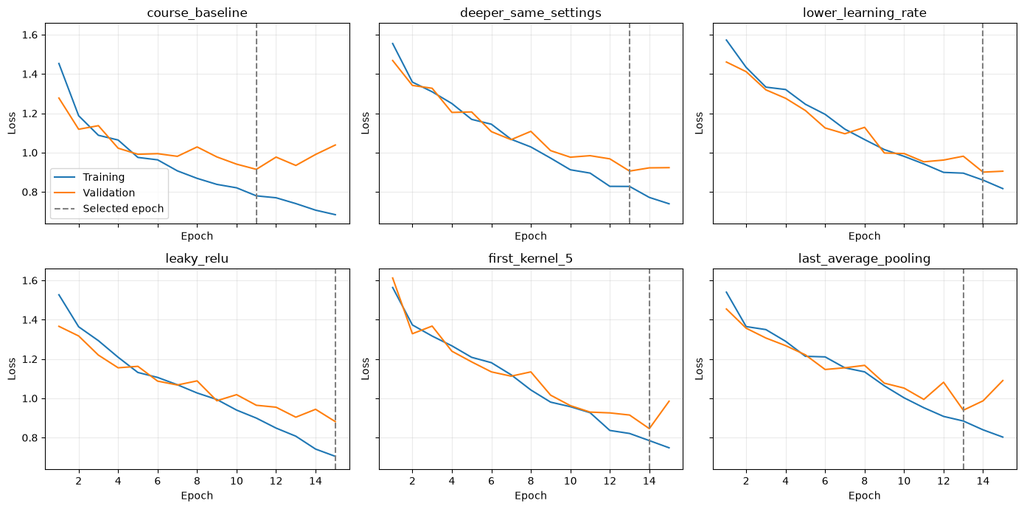

```python
# Include the already-trained deeper reference; do not retrain it here.
flower_deep_reference = json.loads((flower_output_dir / "deeper_metrics.json").read_text())
flower_deep_reference.update({"config": FLOWER_DEFAULT_CONFIG, "checkpoint": "deeper_cnn.pth"})
flower_candidates = [flower_deep_reference] + flower_trial_results
flower_baseline_reference = json.loads((flower_output_dir / "baseline_metrics.json").read_text())
print(f"{'Experiment':<24} {'Epoch':>5} {'Val loss':>10} {'Val accuracy':>13}")
for result in [flower_baseline_reference] + flower_candidates:
    print(f"{result['experiment']:<24} {result['best_epoch']:>5} "
          f"{result['selected_validation_loss']:>10.4f} {result['selected_validation_accuracy']:>13.2%}")

# Select only among the five-block models, as required by the assignment.
# Use the same lowest-validation-loss rule for epochs and for experiment selection.
flower_winner = min(flower_candidates, key=lambda row: row["selected_validation_loss"])
flower_winner_checkpoint = torch.load(
    flower_output_dir / flower_winner["checkpoint"], map_location="cpu", weights_only=True
)
flower_winner_checkpoint["config"] = flower_winner["config"]
flower_winner_checkpoint["experiment"] = flower_winner["experiment"]
flower_winner_checkpoint["selection_rule"] = "lowest validation loss; no test scores used"
flower_selected_path = flower_output_dir / "selected_flower_cnn.pth"
torch.save(flower_winner_checkpoint, flower_selected_path)
flower_selection = {
    "experiment": flower_winner["experiment"], "config": flower_winner["config"],
    "best_epoch": flower_winner["best_epoch"],
    "selected_validation_loss": flower_winner["selected_validation_loss"],
    "selected_validation_accuracy": flower_winner["selected_validation_accuracy"],
    "selection_rule": "lowest validation loss among the five-block models",
    "test_used_for_selection": False,
}
(flower_output_dir / "model_selection.json").write_text(json.dumps(flower_selection, indent=2), encoding="utf-8")
(flower_output_dir / "experiment_comparison.json").write_text(
    json.dumps([flower_baseline_reference] + flower_candidates, indent=2), encoding="utf-8"
)
print(f"Selected: {flower_winner['experiment']} at epoch {flower_winner['best_epoch']}.")

# Same axis limits make comparisons between experiments easier.
fig, axes = plt.subplots(2, 3, figsize=(14, 7), sharex=True, sharey=True)
for ax, result in zip(axes.flat, [flower_baseline_reference] + flower_candidates):
    epochs = np.arange(1, result["epochs"] + 1)
    ax.plot(epochs, result["history"]["train_loss"], label="Training")
    ax.plot(epochs, result["history"]["val_loss"], label="Validation")
    ax.axvline(result["best_epoch"], linestyle="--", color="gray", label="Selected epoch")
    ax.set(title=result["experiment"], xlabel="Epoch", ylabel="Loss")
    ax.grid(alpha=0.25)
axes[0, 0].legend()
plt.tight_layout()
fig.savefig(flower_output_dir / "experiment_learning_curves.png", dpi=120)
plt.show()
```

### 2.16 Final evaluation on the reserved test set

We have completed the planned experiments and fixed the model choice using validation loss.  
Only now do we evaluate the selected checkpoint on the 551 test images.  
The code loads the saved weights and configuration, so the result does not depend on which model remains in memory.

Accuracy is the fraction of correct classifications.  
Balanced accuracy averages recall across the five classes.  
Precision measures how often predictions of a class are correct, as recall measures how many actual examples of that class are found.  
F1 combines precision and recall; support is the number of test examples in that class.

The confusion matrix shows true classes in rows and predicted classes in columns.  
Correct classifications lie on its diagonal.  
The test result is the final estimate for this chosen model, not a reason to tune another model.  
The selected checkpoint and its configuration will also support Problem 3.

```
Selected experiment: first_kernel_5
Selected epoch: 14
Test images: 551
Test loss: 0.8353
Test accuracy: 69.15%
Balanced test accuracy: 68.86%
              precision    recall  f1-score   support

       daisy       0.71      0.63      0.67        95
   dandelion       0.73      0.75      0.74       135
       roses       0.59      0.57      0.58        96
  sunflowers       0.68      0.92      0.79       105
      tulips       0.73      0.57      0.64       120

    accuracy                           0.69       551
   macro avg       0.69      0.69      0.68       551
weighted avg       0.69      0.69      0.69       551
```

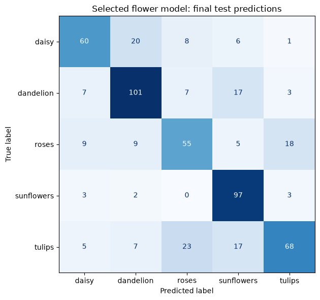

```
Final test results saved. Keep this model fixed for Problem 3.
```

```python
# The experiment choice is already fixed in model_selection.json.
from sklearn.metrics import accuracy_score, balanced_accuracy_score, classification_report, ConfusionMatrixDisplay

flower_output_dir = Path("outputs") / "flowers"
flower_final_selection = json.loads((flower_output_dir / "model_selection.json").read_text())
flower_final_checkpoint = torch.load(
    flower_output_dir / "selected_flower_cnn.pth", map_location=flower_device, weights_only=True
)
assert flower_final_checkpoint["experiment"] == flower_final_selection["experiment"]
assert flower_final_checkpoint["class_names"] == flower_class_names
assert flower_final_checkpoint["image_size"] == FLOWER_IMAGE_SIZE
flower_final_model = build_flower_variant(
    flower_final_checkpoint["config"], len(flower_class_names)
).to(flower_device)
flower_final_model.load_state_dict(flower_final_checkpoint["state_dict"])
flower_final_model.eval()
assert sum(isinstance(layer, nn.Conv2d) for layer in flower_final_model.modules()) == 5
assert sum(isinstance(layer, nn.Linear) for layer in flower_final_model.modules()) == 3
assert isinstance(flower_final_model.classifier[4], nn.ReLU)

# One final test evaluation; these results do not change model selection.
flower_true_labels, flower_predicted_labels = [], []
flower_test_loss_sum = 0.0
flower_final_criterion = nn.CrossEntropyLoss()
with torch.no_grad():
    for images, labels in flower_test_loader:
        scores = flower_final_model(images.to(flower_device))
        assert torch.isfinite(scores).all()
        flower_test_loss_sum += flower_final_criterion(scores, labels.to(flower_device)).item() * len(labels)
        flower_true_labels.extend(labels.tolist())
        flower_predicted_labels.extend(scores.argmax(1).cpu().tolist())
assert len(flower_true_labels) == len(flower_test_dataset)
flower_final_test_loss = flower_test_loss_sum / len(flower_true_labels)
flower_final_test_accuracy = accuracy_score(flower_true_labels, flower_predicted_labels)
flower_final_balanced_accuracy = balanced_accuracy_score(flower_true_labels, flower_predicted_labels)
flower_report = classification_report(
    flower_true_labels, flower_predicted_labels,
    labels=list(range(len(flower_class_names))), target_names=flower_class_names,
    output_dict=True, zero_division=0,
)
print(f"Selected experiment: {flower_final_selection['experiment']}")
print(f"Selected epoch: {flower_final_selection['best_epoch']}")
print(f"Test images: {len(flower_true_labels)}")
print(f"Test loss: {flower_final_test_loss:.4f}")
print(f"Test accuracy: {flower_final_test_accuracy:.2%}")
print(f"Balanced test accuracy: {flower_final_balanced_accuracy:.2%}")
print(classification_report(
    flower_true_labels, flower_predicted_labels,
    labels=list(range(len(flower_class_names))), target_names=flower_class_names,
    zero_division=0,
))
fig, ax = plt.subplots(figsize=(7, 6))
ConfusionMatrixDisplay.from_predictions(
    flower_true_labels, flower_predicted_labels,
    labels=list(range(len(flower_class_names))), display_labels=flower_class_names,
    cmap="Blues", colorbar=False, ax=ax,
)
ax.set_title("Selected flower model: final test predictions")
plt.tight_layout()
fig.savefig(flower_output_dir / "final_test_confusion_matrix.png", dpi=120)
plt.show()
flower_final_test_metrics = {
    "selection": flower_final_selection, "test_images": len(flower_true_labels),
    "test_loss": flower_final_test_loss, "test_accuracy": flower_final_test_accuracy,
    "balanced_test_accuracy": flower_final_balanced_accuracy, "classification_report": flower_report,
    "true_labels": flower_true_labels, "predicted_labels": flower_predicted_labels,
    "checkpoint": "selected_flower_cnn.pth", "test_used_for_selection": False,
}
(flower_output_dir / "final_test_metrics.json").write_text(
    json.dumps(flower_final_test_metrics, indent=2), encoding="utf-8"
)
print("Final test results saved. Keep this model fixed for Problem 3.")
```

### 2.17 Problem 2 conclusions

We trained the original model, added two convolutional blocks and one hidden linear layer with ReLU, ran four controlled trials, selected a checkpoint using validation loss and evaluated it on the reserved test set.  
No data augmentation was used.

| Experiment | Selected epoch | Validation loss | Validation accuracy |
| --- | --- | --- | --- |
| course_baseline | 11 | 0.9146 | 64.18% |
| deeper_same_settings | 13 | 0.9058 | 64.73% |
| lower_learning_rate | 14 | 0.9005 | 65.64% |
| leaky_relu | 15 | 0.8814 | 68.00% |
| first_kernel_5 | 14 | 0.8457 | 67.27% |
| last_average_pooling | 13 | 0.9394 | 63.82% |

**What changed and what we observed**

- Adding the required depth alone gave a small gain: 64.18% to 64.73% validation accuracy, with loss falling from 0.9146 to 0.9058.
- Reducing the learning rate to 0.0005 gave 65.64% validation accuracy and loss 0.9005. It learned more slowly early in the fixed 15-epoch budget, but improved slightly on the deeper reference at its selected checkpoint.
- LeakyReLU in the convolutional blocks gave the highest selected validation accuracy, 68.00%, and loss 0.8814.  
  We retained ReLU after both hidden linear layers.  
  Its best loss occurred at the last planned epoch; this run does not establish whether further training would help.
- A 5 x 5 first kernel gave the lowest validation loss, 0.8457, with 67.27% validation accuracy.  
  It sees a larger local region in the first layer and adds parameters.  
  The measured result supports this configuration on this split, because it does not establish why it helped or that it will always help.
- Average pooling in only the last two blocks gave 63.82% validation accuracy and loss 0.9394, worse than the deeper reference. We did not retain that variant.

**Selection and overfitting**

We selected the 5 x 5 first-kernel model at epoch 14 because its validation loss was lowest. LeakyReLU's higher accuracy did not override the selection rule.  
The selected architecture has five convolutional blocks, three linear layers, ReLU activations and max pooling; its only kernel change is in the first convolution.

Several curves show continued training improvement while validation loss worsens. For the chosen kernel model, validation loss increased from 0.8457 at epoch 14 to 0.9851 at epoch 15.  
We restored epoch 14 instead of using the final weights. Checkpoint selection manages this risk; it does not prove that overfitting is absent. We kept the experiment count small and did not tune using test results.

Each configuration was run with one fixed seed and one fixed split, with 15 epochs and batches of 64. These are exploratory results, not estimates of variation across repeated runs.  
Also, changing a kernel changes both its spatial coverage and parameter count. The comparisons should not be read as isolating a single mathematical cause.

**Final test results**

- Test images: 551.
- Correct classifications: 381.
- Test accuracy: **69.15%**.
- Test loss: **0.8353**.
- Balanced test accuracy: **68.86%**.

Sunflowers had the highest test recall (92.38%).  
Roses had the lowest F1 score (about 0.58).  
The confusion matrix and per-class report above show the remaining errors.  
Validation and test results differ because they measure different sets of images.  
We will not adjust the model in response to these test results.

The assignment's reference to about 75% accuracy should be read with care: the supplied course notebook records 75.1% training accuracy and 65.34% test accuracy.  
Our own rerun provided the baseline for controlled validation comparisons. We do not compare a training percentage directly with a test percentage.

**Saved for Problem 3**

`outputs/flowers/selected_flower_cnn.pth` contains the selected weights, architecture configuration, class order, image size and selected epoch.  
`build_flower_variant` reconstructs the matching architecture; it appears in this notebook and in `flower_variants.py`.  
`split_manifest.json` records the exact image assignments.  
Training histories, experiment results and final test metrics are saved beside the checkpoint.

For Problem 3, the last convolution is `flower_final_model.features[12]`.  
Its output before the final pooling stage has shape `(batch, 256, 4, 4)`, so a Grad-CAM heatmap from that layer will have coarse spatial resolution before being enlarged for display.

The following sections use the selected flower checkpoint for Problem 3.

## Problem 3: inspect the selected flower CNN

Adapted from `3_Visualizing_Flower_CNN_Filters_PyTorch.ipynb`.  
We load the final model from Problem 2, inspect a daisy through all five convolutional blocks, compare the last-block maps for roses and tulips, and generate Grad-CAM heatmaps.  
No model is trained here.

### 3.1 Restore the exact architecture and select images

The selected model has a 5 x 5 first kernel, five convolutional blocks and three linear layers.  
ReLU follows both hidden linear layers. Loading a different architecture would not reproduce the trained model.  
The checkpoint configuration reconstructs the architecture, and `load_state_dict` restores the learned weights.

We use the same RGB resize and tensor conversion as training.  
For each flower type, we choose the first filename in its saved validation subset, independently of prediction or heatmap appearance.  
These are illustrative examples, not a new performance evaluation.

```
Loaded experiment: first_kernel_5 | epoch: 14
Configuration: {'learning_rate': 0.001, 'activation': 'relu', 'first_kernel': 5, 'last_pooling': 'max'}
features[0]: weights (16, 3, 5, 5)
features[3]: weights (32, 16, 3, 3)
features[6]: weights (64, 32, 3, 3)
features[9]: weights (128, 64, 3, 3)
features[12]: weights (256, 128, 3, 3)
daisy: daisy/10140303196_b88d3d6cec.jpg | predicted daisy (74.7%)
roses: roses/10503217854_e66a804309.jpg | predicted tulips (52.8%)
tulips: tulips/107693873_86021ac4ea_n.jpg | predicted tulips (54.3%)
```

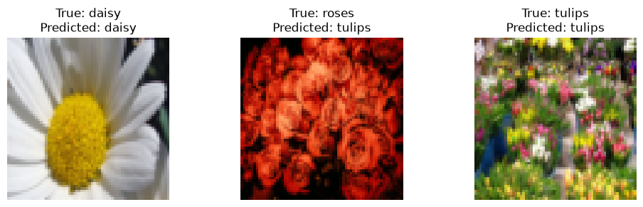

```python
from pathlib import Path
import json
import numpy as np
import matplotlib.pyplot as plt
from PIL import Image
import torch
from torch import nn
from torchvision import transforms

# Reuse the architecture definitions above, or import them in a fresh kernel.
if "build_flower_variant" not in globals():
    from flower_variants import build_flower_variant

p3_checkpoint_path = Path("outputs/flowers/selected_flower_cnn.pth")
p3_checkpoint = torch.load(p3_checkpoint_path, map_location="cpu", weights_only=True)
p3_classes = p3_checkpoint["class_names"]
p3_model = build_flower_variant(p3_checkpoint["config"], len(p3_classes))
p3_model.load_state_dict(p3_checkpoint["state_dict"], strict=True)
p3_model.eval()
p3_model.requires_grad_(False)  # Grad-CAM will track the input instead of parameter gradients.
p3_output = Path("outputs") / "problem3"
p3_output.mkdir(parents=True, exist_ok=True)
p3_transform = transforms.Compose([
    transforms.Resize((p3_checkpoint["image_size"], p3_checkpoint["image_size"])),
    transforms.ToTensor(),
])
assert sum(isinstance(layer, nn.Conv2d) for layer in p3_model.modules()) == 5
assert sum(isinstance(layer, nn.Linear) for layer in p3_model.modules()) == 3
assert isinstance(p3_model.classifier[4], nn.ReLU)
print("Loaded experiment:", p3_checkpoint["experiment"], "| epoch:", p3_checkpoint["best_epoch"])
print("Configuration:", p3_checkpoint["config"])
for index, layer in enumerate(p3_model.features):
    if isinstance(layer, nn.Conv2d):
        print(f"features[{index}]: weights {tuple(layer.weight.shape)}")

# Pick the first filename in each chosen class from the saved validation split.
# Selection does not depend on predictions or how attractive a heatmap looks.
p3_manifest = json.loads(Path("outputs/flowers/split_manifest.json").read_text())
p3_photos = {}
for name in ["daisy", "roses", "tulips"]:
    relative_path = sorted(s for s in p3_manifest["splits"]["validation"] if Path(s).parts[0] == name)[0]
    path = Path("data/flower_photos") / relative_path
    with Image.open(path) as picture:
        tensor = p3_transform(picture.convert("RGB")).unsqueeze(0)
    with torch.no_grad():
        scores = p3_model(tensor)
        probabilities = scores.softmax(1)[0]
    predicted = int(probabilities.argmax())
    p3_photos[name] = {"path": relative_path, "input": tensor, "true_index": p3_classes.index(name),
                       "predicted_index": predicted, "score": float(probabilities[predicted])}
    print(f"{name}: {relative_path} | predicted {p3_classes[predicted]} ({float(probabilities[predicted]):.1%})")
fig, axes = plt.subplots(1, 3, figsize=(10, 3))
for ax, (name, item) in zip(axes, p3_photos.items()):
    ax.imshow(item["input"][0].permute(1, 2, 0))
    ax.set_title(f"True: {name}\nPredicted: {p3_classes[item['predicted_index']]}")
    ax.axis("off")
plt.tight_layout();fig.savefig(p3_output / "selected_inputs.png", dpi=120);plt.show()
```

### 3.2 Inspect actual filter weights

A filter consists of learned weights, not an image or a feature map.  
The first convolution has weight shape `(16, 3, 5, 5)`: 16 filters, three input-channel slices per filter, and a 5 x 5 spatial kernel.  
Each filter combines all three slices to produce one output feature map, and has a separate bias.

We show six filters' RGB slices with a common signed colour scale: blue is negative and red is positive.  
These colours encode numerical weights, not the colours of objects the filters detect.  
This compact plot avoids the enormous grids that would result from plotting every slice in the deeper layers.

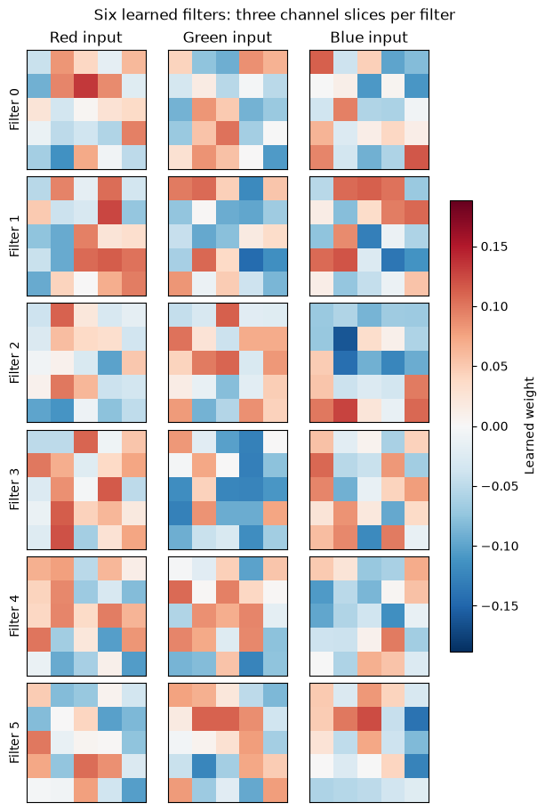

```python
# Read six first-layer filters. Each has three 5 x 5 channel slices.
p3_filters = p3_model.features[0].weight.detach()
p3_limit = max(float(p3_filters.abs().max()), 1e-8)
fig, axes = plt.subplots(6, 3, figsize=(6, 9), layout="constrained")
for f in range(6):
    for channel in range(3):
        ax = axes[f, channel]
        picture = ax.imshow(p3_filters[f, channel], cmap="RdBu_r", vmin=-p3_limit, vmax=p3_limit,
                            interpolation="nearest")
        ax.set_xticks([]);ax.set_yticks([])
        if f == 0:ax.set_title(["Red input", "Green input", "Blue input"][channel])
        if channel == 0:ax.set_ylabel(f"Filter {f}")
fig.colorbar(picture, ax=axes, shrink=0.6, label="Learned weight")
fig.suptitle("Six learned filters: three channel slices per filter")
fig.savefig(p3_output / "first_layer_filters.png", dpi=120);plt.show()
```

### 3.3 Follow a daisy through all five blocks

We pass the same image through the loaded model and copy maps after each ReLU, before pooling.  
Their spatial sizes are 64, 32, 16, 8 and 4 pixels per side; channel counts are 16, 32, 64, 128 and 256.  
A check confirms that this walkthrough produces the same scores as the normal forward pass.

Only the first eight channels per block are displayed, chosen consistently rather than by their apparent interpretability.  
Each daisy row has its own scale. A dark map can be a valid response.  
For roses and tulips, we compare the same eight last-block channels on one shared scale.  
These 4 x 4 maps are coarse responses, not outlines of petals or proof of a channel's meaning.

```
Daisy, block 1: (1, 16, 64, 64) after ReLU, before pooling
Daisy, block 2: (1, 32, 32, 32) after ReLU, before pooling
Daisy, block 3: (1, 64, 16, 16) after ReLU, before pooling
Daisy, block 4: (1, 128, 8, 8) after ReLU, before pooling
Daisy, block 5: (1, 256, 4, 4) after ReLU, before pooling
```

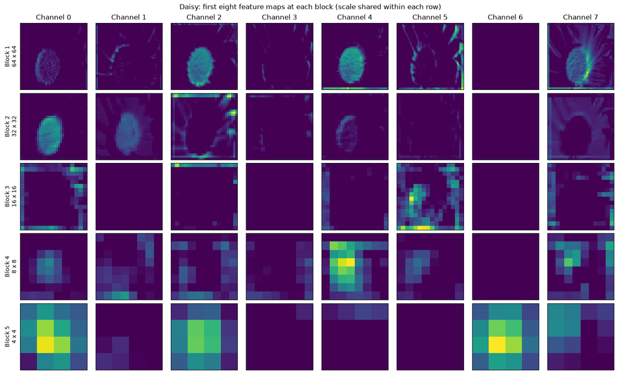

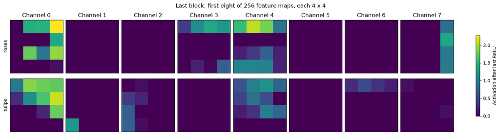

```python
def trace_flower_features(input_tensor):
    """Return feature maps after each ReLU, before pooling, and verify the forward pass."""
    maps = {}
    current = input_tensor
    block = 0
    with torch.no_grad():
        for layer in p3_model.features:
            if isinstance(layer, nn.Conv2d):
                block += 1
            current = layer(current)
            if isinstance(layer, (nn.ReLU, nn.LeakyReLU)):
                maps[block] = current.clone()
        scores = p3_model.classifier(current)
        torch.testing.assert_close(scores, p3_model(input_tensor))
    return maps

p3_daisy_maps = trace_flower_features(p3_photos["daisy"]["input"])
fig, axes = plt.subplots(5, 8, figsize=(15, 9), layout="constrained")
for row, (block, maps) in enumerate(p3_daisy_maps.items()):
    print(f"Daisy, block {block}: {tuple(maps.shape)} after ReLU, before pooling")
    shown = maps[0, :8]
    upper = max(float(shown.max()), 1e-8)
    for channel, ax in enumerate(axes[row]):
        ax.imshow(shown[channel], cmap="viridis", vmin=0, vmax=upper, interpolation="nearest")
        ax.set_xticks([]);ax.set_yticks([])
        if row == 0:ax.set_title(f"Channel {channel}")
        if channel == 0:ax.set_ylabel(f"Block {block}\n{maps.shape[-1]} x {maps.shape[-1]}")
fig.suptitle("Daisy: first eight feature maps at each block (scale shared within each row)")
fig.savefig(p3_output / "daisy_all_blocks.png", dpi=120);plt.show()

# Compare the same channel indices for roses and tulips with a shared scale.
p3_last_maps = {name: trace_flower_features(p3_photos[name]["input"])[5][0, :8]
                for name in ["roses", "tulips"]}
upper = max(max(float(maps.max()) for maps in p3_last_maps.values()), 1e-8)
fig, axes = plt.subplots(2, 8, figsize=(15, 4), layout="constrained")
for row, (name, maps) in enumerate(p3_last_maps.items()):
    for channel, ax in enumerate(axes[row]):
        picture = ax.imshow(maps[channel], cmap="viridis", vmin=0, vmax=upper, interpolation="nearest")
        ax.set_xticks([]);ax.set_yticks([])
        if row == 0:ax.set_title(f"Channel {channel}")
        if channel == 0:ax.set_ylabel(name)
fig.colorbar(picture, ax=axes, shrink=0.7, label="Activation after last ReLU")
fig.suptitle("Last block: first eight of 256 feature maps, each 4 x 4")
fig.savefig(p3_output / "roses_tulips_last_block.png", dpi=120);plt.show()
```

### 3.4 Generate Grad-CAM for the selected flowers

Grad-CAM combines feature maps using gradients of a chosen class score.  
We use maps after the final ReLU (`features[13]`), before the last pooling layer. The original three-block notebook's indices must therefore change.

For each image, we explain its **true flower class**, named in the plot, and separately report the model's predicted class.  
We differentiate the raw class score with respect to the maps, average gradients over spatial positions, weight and sum the maps, and retain positive responses.  
We enlarge the 4 x 4 result to the 64 x 64 input size for display.  
Each heatmap is scaled independently to 0-1, so its colours are relative, not probabilities or comparable absolute importance across images.

`eval()` selects evaluation behaviour but still allows gradients.  
We track the input, keep model parameters frozen, and never call an optimiser. An all-zero map would be reported rather than replaced by a more attractive example. Grad-CAM is a coarse diagnostic, because it cannot establish that the network understands flowers or identify a precise causal explanation.

```
daisy: explaining daisy; positive Grad-CAM response: True
roses: explaining roses; positive Grad-CAM response: True
tulips: explaining tulips; positive Grad-CAM response: True
```

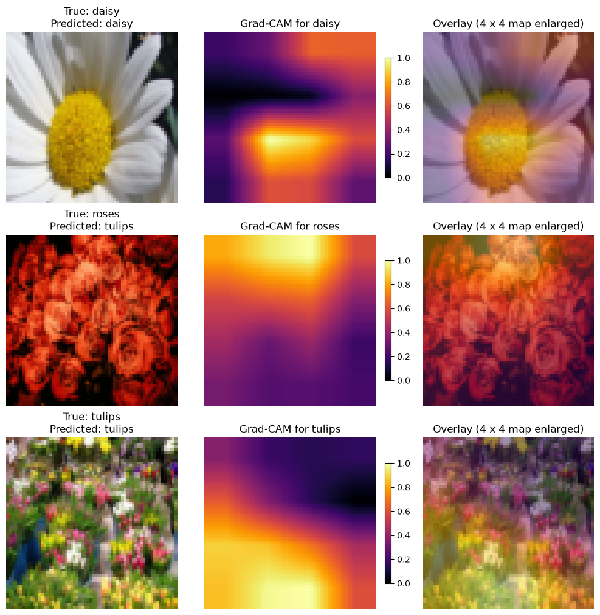

```
All model weights and biases are unchanged. No training was performed.
```

```python
import torch.nn.functional as F

def flower_gradcam(input_tensor, target_index):
    """Explain a named class using the final ReLU maps, without changing weights."""
    # Evaluation mode does not disable gradients. Track a fresh input for this calculation.
    tracked_input = input_tensor.detach().clone().requires_grad_(True)
    maps = p3_model.features[:14](tracked_input)  # Includes last convolution [12] and ReLU [13].
    pooled = p3_model.features[14:](maps)         # Last pooling layer [14].
    scores = p3_model.classifier(pooled)
    torch.testing.assert_close(scores.detach(), p3_model(input_tensor).detach())
    gradients = torch.autograd.grad(scores[0, target_index], maps)[0]
    weights = gradients.mean(dim=(2, 3), keepdim=True)
    coarse = (weights * maps).sum(dim=1, keepdim=True).relu().detach()
    assert coarse.shape == (1, 1, 4, 4)
    enlarged = F.interpolate(coarse, size=input_tensor.shape[-2:], mode="bilinear", align_corners=False)[0, 0]
    peak = float(enlarged.max())
    heatmap = enlarged / max(peak, 1e-8)
    assert torch.isfinite(heatmap).all()
    return heatmap.numpy(), coarse[0, 0].numpy(), peak

# Explain each true flower class explicitly, even if the predicted class differs.
p3_cam_results = {}
fig, axes = plt.subplots(3, 3, figsize=(10, 10), layout="constrained")
for row, (name, item) in enumerate(p3_photos.items()):
    heatmap, coarse, peak = flower_gradcam(item["input"], item["true_index"])
    rgb = item["input"][0].permute(1, 2, 0).numpy()
    axes[row, 0].imshow(rgb)
    axes[row, 0].set_title(f"True: {name}\nPredicted: {p3_classes[item['predicted_index']]}")
    picture = axes[row, 1].imshow(heatmap, cmap="inferno", vmin=0, vmax=1)
    axes[row, 1].set_title(f"Grad-CAM for {name}")
    axes[row, 2].imshow(rgb)
    axes[row, 2].imshow(heatmap, cmap="inferno", vmin=0, vmax=1, alpha=0.45)
    axes[row, 2].set_title("Overlay (4 x 4 map enlarged)")
    for ax in axes[row]:ax.axis("off")
    fig.colorbar(picture, ax=axes[row, 1], shrink=0.7)
    np.save(p3_output / (name + "_gradcam.npy"), heatmap)
    p3_cam_results[name] = {
        "image": item["path"], "true_class": name,
        "predicted_class": p3_classes[item["predicted_index"]], "model_score": item["score"],
        "explained_class": name, "coarse_shape": list(coarse.shape),
        "positive_response": peak > 0,
    }
    print(f"{name}: explaining {name}; positive Grad-CAM response: {peak > 0}")
fig.savefig(p3_output / "gradcam_overlays.png", dpi=140);plt.show()
# Confirm that inspection and gradient calculations have not changed any model parameters.
for name, value in p3_model.state_dict().items():
    torch.testing.assert_close(value, p3_checkpoint["state_dict"][name], rtol=0, atol=0)
(p3_output / "visualisation_results.json").write_text(json.dumps(p3_cam_results, indent=2), encoding="utf-8")
print("All model weights and biases are unchanged. No training was performed.")
```

### 3.5 What the visualisations show

The early daisy maps retain recognisable edges and regions around the yellow centre and white petals.  
Later maps have less spatial detail: the fifth block has 256 channels, each only 4 x 4 before pooling.  
Increasing channels does not preserve pixel resolution.  
The rose and tulip plots use the same eight channels and a shared scale, because their different responses show how the same learned filters respond to different inputs.  
A dark channel for these images does not establish that it is inactive for every image.

| Image | Prediction | Interpretation of Grad-CAM for the true class |
| --- | --- | --- |
| Daisy | Daisy (74.7% model score) | The strongest region overlaps the yellow centre and nearby petal bases. This is consistent with attention to the flower. |
| Roses | Tulips (52.8% model score) | The **roses-class** map emphasises a broad upper region containing red blooms. It does not explain the winning tulips score, and flower overlap did not guarantee correct classification. |
| Tulips | Tulips (54.3% model score) | The strongest region lies towards the lower left and centre, overlapping flowers and foliage. This is mixed evidence; the plot does not clearly isolate distinctive flower parts. |

These are qualitative observations from three fixed validation examples, not a localisation benchmark.  
The original heatmaps contain only 16 spatial values. Smooth enlargement makes them easier to overlay but adds no spatial evidence.  
Their colours show relative positive contributions to the chosen class score, not the probability that a pixel belongs to a flower.  
We retained the incorrect rose prediction and did not select replacement images or tune the model from these plots.

**Completion check:**  
Problem 3 loads the model selected in Problem 2, shows learned filter weights, follows a daisy through all five blocks, compares last-block maps for roses and tulips, and creates and interprets Grad-CAM for both additional flower types (and the daisy).  
The forward-pass checks passed and every saved model parameter remained unchanged.  
No retraining was needed.  
Plots and image-level results are saved in `outputs/problem3/`.